# beatochess no. 12 (September 2025)

Beat Neuenschwander, neuenschwander.beat@gmail.com, https://github.com/beatochess/

# Awards

## Mario Garcia Memorial 2025

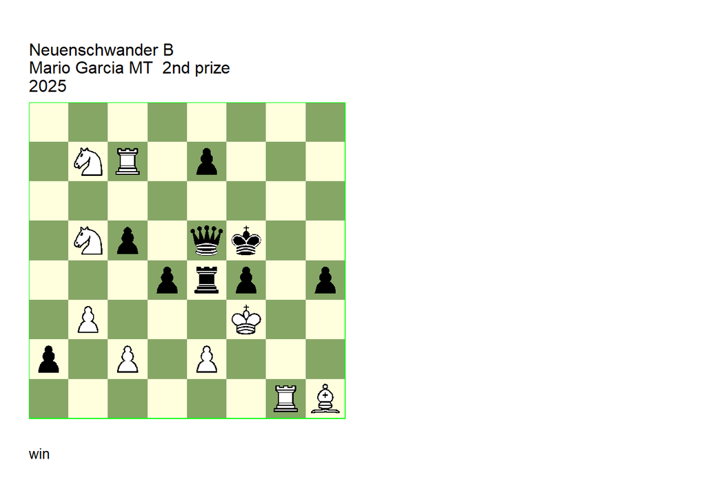

GBR: +3512.36f3f5 FEN: 8/1NR1p3/8/1Np1qk2/3prp1p/1P3K2/p1P1P3/6RB w - - 0 1

**1. N5d6+!** (1. Rxc5? Re3+ 2. Kf2 Rxe2+ 3. Kf3 Re3+ =) **1… exd6 2. Rf7+ Ke6 3. Nd8+ Kd5 4. c4+! dxc3 5. Rd1+ Qd4** (5… Rd4 6. Kf2+) **6. Rf5+ Re5 7. e4+!** (7. Kg4+? f3+) **7… fxe3 8. Ke2#** Two en-passant captures prelude mate with two pinned pieces. **1-0**.

## The Problemist 2024

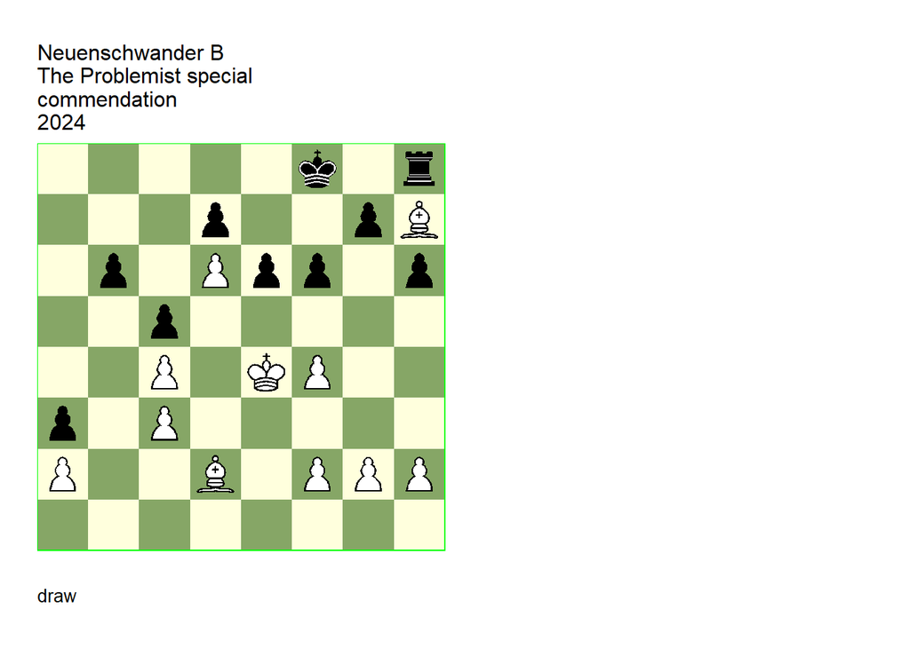

GBR: =0320.88e4f8 FEN: 5k1r/3p2pB/1p1Ppp1p/2p5/2P1KP2/p1P5/P2B1PPP/8 w - - 0 1

**1. Bg6 f5+ 2. Ke5!** (2. Kd3? h5 3. h4 Rh6 4. g4 Rxg6 5. g5 Ke8! (5… e5? 6. fxe5 Re6 7. f4) 6. Kc2 Kd8 7. Kb3 Kc8 8. Ka4 Kb7 9. Kb5 e5 10. fxe5 Re6 11. f4 Re8 12. Ka4 Ra8+ 13. Kb3 Kc6 14. Bc1 Ra5 15. Bxa3 b5 -/+) **2… h5 3. h4 Rh6 4. g4!! Rxg6 5. g5 Kf7 6. Bc1!** Tempo! (6. Be3? Rf6 7. Bxc5 bxc5 8. f3 Kg6 Zugzwang 9. gxf6 gxf6#) (6. f3? Rf6 7. Be3 Kg6 8. Bf2 Rf8 9. Bxc5 Rc8 -/+) **6… Rf6 7. Be3!** (7. Bxa3? Kg6 8. Bc1 Rf8 -/+) **7… Kg6 8. Bxc5!** (8. f3? Rf8 9. Bxc5 Rc8 -/+) **8… bxc5 9. f3** Now Black is in Zugzwang **9… Kf7 10. g6+ 1/2-1/2**.

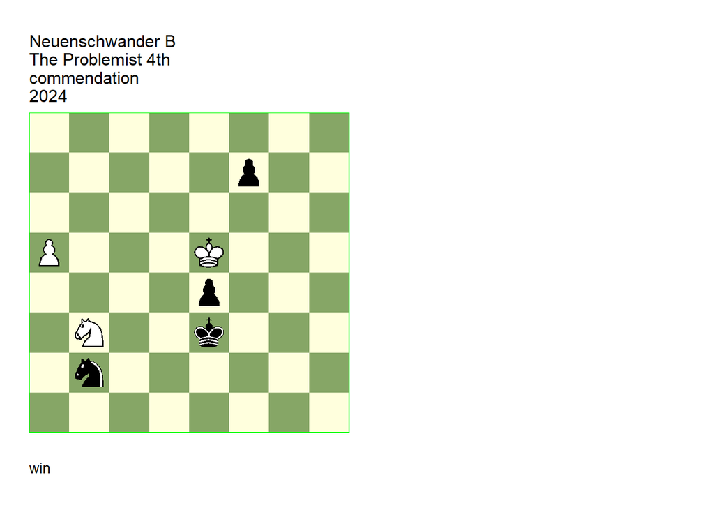

GBR: +0004.12e5e3 FEN: 8/5p2/8/P3K3/4p3/1N2k3/1n6/8 w - - 0 1

**1. Kd5** (1. a6? Nc4+) **1… Na4** (1… Nd3 2. Kc4 Nf4 (2… Ne5+ 3. Kb5 Nd7 4. a6) 3. Nd4! Ng6 4. Nf5+! (4. a6? Ne5+! (4… Ne7? 5. Nf5+) 5. Kb5 Kxd4 6. a7 e3 7. a8=Q e2 =) 4… Kf4 5. a6 Ne5+ 6. Kb5 Kxf5 7. a7 e3 8. a8=Q e2 9. Qh1 +-) (1… f5 2. a6 f4 3. a7 Na4 4. Kc6 = **main** line ) **2. Kc6 f5 3. a6 f4 4. a7 Nb6! 5. Kxb6 f3 6. Na5!!** The climax of the study. (6. a8=Q? f2 7. Qf8 (7. Qa6 or ) 7… f1=Q 8. Qxf1) (6. Nd2? Kxd2 7. a8=Q f2 8. Qd5+ Ke2 9. Qxe4+ Kf1 =) (6. a8=R? f2 7. Ra1 (7. Rf8 Ke2 8. Nd4+ Ke1 ) 7… Kf4! 8. Kc5 e3 9. Nd4 Kg3 10. Kc4 Kg2) **6… f2 7. Nc4+ Kd3** (7… Ke2 8. a8=Q f1=Q 9. Qa2+ (9. Qxe4+? Kf2 =) 9… Kd3 10. Qb3+ Kd4 11. Nb2 leads to the **main** variation ) **8. a8=Q f1=Q 9. Qa3+** (9. Qd5+? Ke2 10. Qxe4+ Kf2 = ) **9… Kd4** (9… Kxc4 10. Qa6+) (9… Kc2 10. Ne3+) (9… Ke2 10. Qe3+) **10. Qb2+** (10. Qc5+ Kd3 11. Qa3+ waste of time ) **10… Kd3** (10… Kd5 11. Ne3+) **11. Ne5+ Ke3 12. Ng4+ Kf4** (12… Kf3 13. Nh2+) (12… Kd3 13. Kb5) **13. Qf6+ 1-0**.

# New publications

## Die Schwalbe 2025

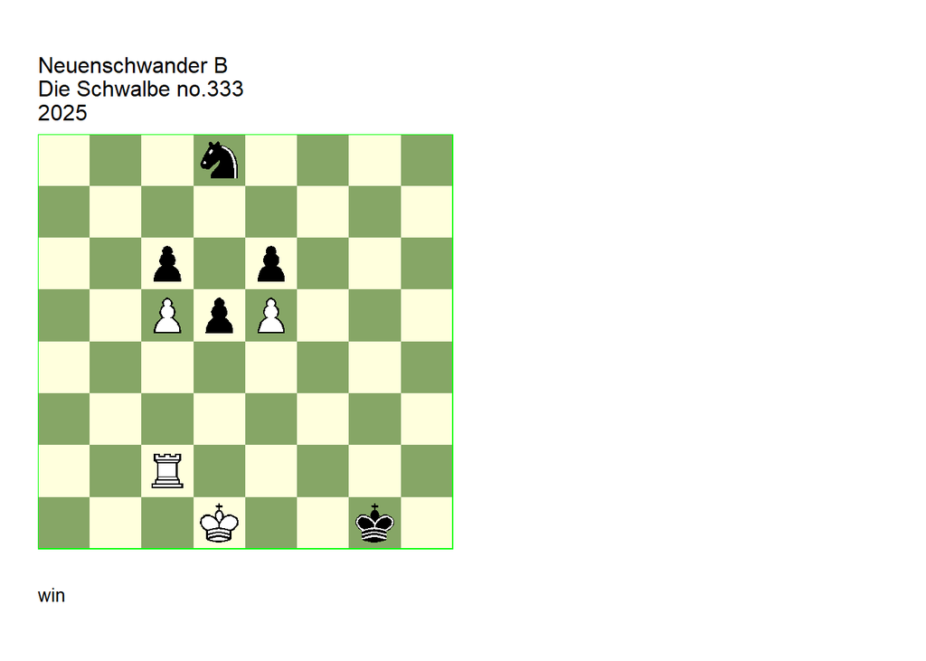

GBR: +0103.23d1g1 FEN: 3n4/8/2p1p3/2PpP3/8/8/2R5/3K2k1 w - - 0 1

**1. Rd2!** Keeping the black knight at d8. (1. Ke1? Nf7 2. Re2 Ng5) **1… Kf1** (1… Nf7 (or 1…Nb7) 2. Rxd5!! see move 5 of the **main** line ) **2. Rh2!** (2. Re2? Nf7 3. Kd2 Kg1! (3… Ng5? 4. Ke3! Ne4 5. Rh2 Nxc5 6. Rh7 Kg2 7. Rc7) 4. Kc3 (4. Kd3 Kf1!) 4… Ng5! (4… Kf1? 5. Kd3 Kg1 6. Kd4 Ng5 7. Ke3) 5. Ra2 (5. Kd3 Nf3) (5. Re3 Kf2 6. Kd4 Nf3+ 7. Kd3 Ne1+) 5… Nf3 6. Ra6 Nxe5 7. Kd4 Nf3+ 8. Ke3 Ne5) (2. Kc2? Ke1! (2… Nb7? 3. Rxd5!!) (2… Nf7? 3. Rxd5!!) 3. Kc3 (3. Kd3 Nf7 4. Re2+ Kf1 5. Kd2 Kg1! see 2.Re2 ) 3… Nb7) **2… Nb7** (2… Nf7 3. Rh5! Kf2 (3… Kg2 4. Rf5) 4. Rf5+! exf5 5. e6) **3. Rc2 Nd8** (3… Na5 4. Rb2! Nc4 5. Re2! Na5 6. Kd2 Nb3+ ( 6… Nc4+ 7. Kd3) 7. Ke3 Nxc5 8. Rf2+ Kg1 9. Rf7 Kg2 10. Rc7) **4. Rd2!** Zugwang! **4… Nb7** (4… Nf7 5. Rxd5!! cxd5 (5… exd5 6. e6) (5… Kf2 6. Rd6 Nxe5 7. Rxe6) 6. c6) (4… Kg1 5. Ke1) **5. Rxd5!! Kf2** (5… cxd5 6. c6) ( 5… exd5 6. e6) **6. Rd6!** (6. Kd2?? cxd5 7. c6 Na5) **6… Ke3** (6… Nxc5 7. Rxc6 Nd3 8. Rxe6 Ke3 9. Re8! Ke4 10. e6 Ke5 11. Rd8 (11. e7? Ke6 12. Rd8 Nf2+) ) **7. Rxe6!** (7. Rxc6? Kd4 8. Rxe6 Nxc5 9. Re8 Kd5) **7… Kd4 8. Rxc6 Kd5** (8… Kxe5 9. Rc7 Nd8 10. Rd7) **9. e6! Kxc6 10. e7 Kd7 11. c6+ 1-0**.

## Problem Paradise 2025

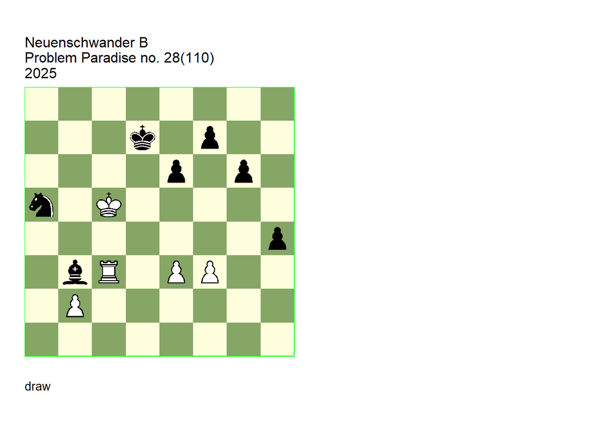

GBR: =0133.34c5d7 FEN: 8/3k1p2/4p1p1/n1K5/7p/1bR1PP2/1P6/8 w - - 0 1

**1. Kb4!** (1. Kb5? Ke7! 2. Kxa5 (2. Rc7+ Kd6 3. Rc1 Nc4) 2… Bd1) **1… Bd5** (1… Bc4 2. Kxa5 Bf1 (2… Be2 3. Rc2 Bxf3 4. Rf2 Bd5 5. Rxf7+ Kc6 6. Rh7 g5 7. Rh5) 3. Rb3! h3 (3… Kc7 4. Rc3+ Kd7 5. Rb3) (3… e5 4. Rb8 h3 5. Rh8) (3… Ke7 4. Rb8 Kf6 5. Rh8 h3 6. b4 Kg7 7. Rh4 g5 8. Rh5 Kg6 9. Rh8) 4. Rb8 e5 5. Rh8 g5 (5… Ke6 6. b4) 6. b4 e4 7. fxe4 g4 8. b5 Bg2 9. b6 Bxe4) (1… Ke7 2. Rc7+ Kf8 (2… Kf6 3. Kxa5) 3. Rc1!) **2. e4 Nc6+ 3. Kc5 Ba2 4. Ra3 Bb1 5. Ra1 Bc2 6. Rc1 Bb3 7. Rc3 Ba2** (7… Ba4 8. Ra3 leads to the **main** line ) ( 7… h3 8. Rxb3 h2 9. Rd3+ Kc7 10. Rd1 Ne5 11. Rh1) **8. Ra3 Bb1 9. Ra1 Bc2 10. Rc1 Ba4 11. Ra1** Now the carrousel turns in the other direction (11. b3 Bxb3 12. Rb1 Ba4 13. Ra1 h3 14. Rxa4 h2 15. Ra1 Ne5) (11. Rc4? Bd1) **11… Bb3 12. Ra3 Bc2 13. Rc3 Bb1 14. Rc1 Ba2 15. Ra1 Bb3 16. Ra3 1/2-1/2**.

## Ceskoslovensky Sach 2025

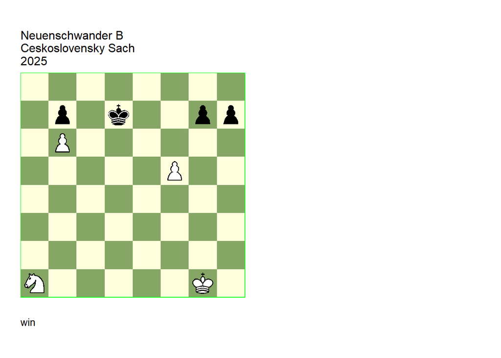

GBR: +0001.23g1d7 FEN: 8/1p1k2pp/1P6/5P2/8/8/8/N5K1 w - - 0 1

**1. Nb3!** (1. Nc2? g6! =) **1… Kd6** (1… Kc6 2. Nd4+ Kxb6 3. Ne6 +-) **2. Nd4 h5** (2… g6 3. f6) **3. Ne2!** (3. Kf2? Ke5 4. Ke3 h4 =) (3. Ne6? g6! =) **3… Ke5** (3… h4 4. Nf4 Ke5 5. Nh5 = **main** ) **4. Ng3 h4 5. Nh5 Kxf5 6. Nxg7+ Ke5 7. Ne8 Kd5 8. Nc7+ Kc6 9. Na8** The white knight moves from corner to corner, taking, a long 9-move route (instead of the shortest possible 5-move route). **1-0**.

# Comments and revisions

## Prize winners

### Dobrescu +0302.22h4h2 (1976). Version

Date: September 8, 2025

File: Dobrescu1976a.pgn

In the sideline of the correction, after **4. Kh5 Kxg2** Black loses, whereas the “better” **4… Rc5+** leads to the mainline. Due to the Rc5+ resource the original study is correct. The version takes advantage of this and extends the study by one move.

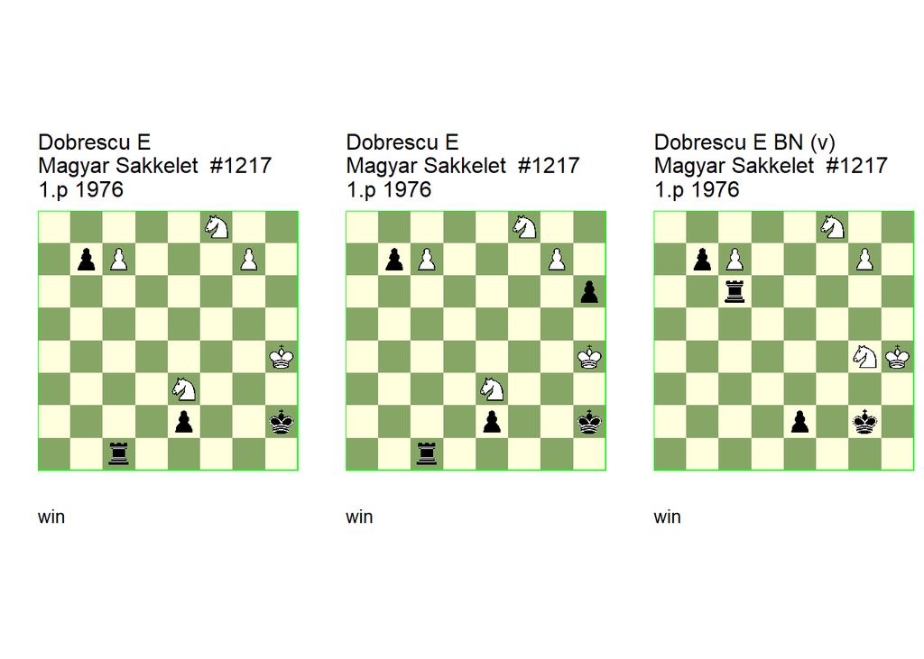

GBR: +0302.22h4h2 U2 FEN: 5N2/1pP3P1/8/8/7K/4N3/4p2k/2r5 w - - 0 1

Magyar Sakkelet/11 6.p Rumanian champ 1976-1977 Revista de Romana de Sah/1 1979 (EG#03295). U2: Van, der, Heijden=H EBUR=4 12/1997. Comment: Neuenschwander=B beatochess 08/09/2025.. **1. Ng2! Rc4+** (1… Kxg2 2. g8=Q+ Kf2 3. Qf7+ Kg2 4. Qg6+ Kf2 5. Qf5+ Ke1 (5… Kg2 6. Qg5+) 6. c8=Q) **2. Kh5** (2. Kg5! **cook** HH 2… Kxg2 (2… Rc5+! 3. Kh4 Rc4+ 4. Kg5 Rc5+ 5. Kh6 Rc6+ leads to the **main** line ) 3. g8=Q Rxc7 4. Qd5+ Kf2 5. Qf5+ Kg2 6. Qe4+ Kf2 7. Qf4+ Kg2 8. Qe3 Rc2! 9. Ne6 Kf1 10. Qf3+ Kg1 11. Qg4+! Kf2 12. Qf5+ Kg1 ( 12… Kg2 13. Qxc2) 13. Nd4 e1=Q 14. Nf3+) **2… Rc5+ 3. Kh6 Rc6+! 4. Ne6!** ( 4. Kg5? Kxg2) (4. Kh7? Rxc7) **4… Kxg2** (4… Rxe6+ 5. Kh7 Re8 6. Ne1) **5. g8=Q+ Kh2!** (5… Kh1 6. Qg3) (5… Kf2 6. Qf7+) **6. Qb8! e1=Q** (6… Kg1 7. c8=Q Rxc8 (7… e1=Q 8. Qg8+ Kf2 9. Qf4+) 8. Qg3+ Kf1 9. Qf3+ Ke1 10. Nd4) ( 6… Kh3 7. c8=Q Rxc8 8. Qe5 Rc2 9. Nd4) **7. c8=Q+ Kh3 8. Qh8!** (8. Qd8? Rxe6+ 9. Kg7 (9. Kh7 Qe4+ 10. Kg7 Qg6+) 9… Qg1+ 10. Kf8 Qf1+ 11. Kg7 Qg2+ 12. Kf8 Qf3+ 13. Kg7 Qg4+ 14. Kf8 Qf5+ 15. Kg7 Qg6+ 16. Kh8 (16. Kf8 Rf6+) 16… Qh6+ 17. Kg8 Rg6+ 18. Kf7 Rg7+ 19. Kf8 Qh8#) (8. Qf8? Rxe6+ 9. Kg7 (9. Kh7 Qh4+ 10. Kg7 Qh6+ 11. Kg8 Rg6+) 9… Re7+ 10. Kg6 Qe6+ 11. Qf6 (11. Kg5 Qg4+ 12. Kh6 Qh4+ 13. Kg6 Qg4+ 14. Kf6 Qe6+ 15. Kg5 Qg4+) 11… Qg4+ 12. Kh6 Re6) ( 8. Qg8? Rxe6+ 9. Kg7 (9. Kg5 Qh4+ 10. Kf5 Qf6#) (9. Kh7 Qh4+ 10. Kg7 Qf6+ 11. Kh7 Qh6#) 9… Qc3+ 10. Kh7 (10. Kf8 Qc5+ 11. Kg7 Qd4+) 10… Qd3+ 11. Kh8 Rh6+ 12. Kg7 Rg6+) **8… Rxe6+** eg (8… Qe3+ 9. Kg6+ Kg2 10. Qbh2+ Kf1 11. Q8h3+) (8… Qg1 9. Qbe5 Rc4 10. Nf4+) **9. Kg5+ Kg2 10. Qhh2+ Kf1** (10… Kf3 11. Qbf4#) **11. Qbf4+ 1-0**.

GBR: +0302.23h4h2 (c) FEN: 5N2/1pP3P1/7p/8/7K/4N3/4p2k/2r5 w - - 0 1

Magyar Sakkelet/11 6.p Rumanian champ 1976-1977. correction: Dobrescu=E EBUR=3 9/1998. Comment: Neuenschwander=B beatochess 08/09/2025. **1. Ng2 Rc4+** (1… Kxg2 2. g8=Q+ Kf2 3. Qf7+) **2. Kh5 Rc5+ 3. Kxh6 Rc6+ 4. Ne6!** (4. Kg5? Kxg2 5. g8=Q e1=Q) (4. Kh5 Kxg2? (4… Rc5+! 5. Kh4 Rc4+ 6. Kg5 Rc5+ 7. Kh6 Rc6+ leads to the **main** line ) 5. g8=Q+ Kf1 6. Qf7+ Kg1 7. Qg7+ (7. c8=Q! **cook** **BN** 7… Rxc8 8. Qg6+ Kf2 9. Qf5+ Kg1 10. Qg4+ Kf2 11. Qf4+ Kg2 12. Qe3 Kf1 13. Qf3+) 7… Kf1 8. Qf7+ Kg1 9. Qe7 Kf1) **4… Kxg2** (4… Rxe6+ 5. Kh7 Re8 6. Ne1) **5. g8=Q+ Kh2! 6. Qb8! e1=Q** (6… Kg1 7. c8=Q Rxc8 (7… e1=Q 8. Qg8+ Kf1 9. Qf4+) 8. Qg3+ Kf1 9. Qf3+ Ke1 10. Nd4) (6… Kh3 7. c8=Q Rxc8 8. Qe5 Rc2 9. Nd4) **7. c8=Q+ Kh3 8. Qh8!** (8. Qg8? Rxe6+ 9. Kg7 Qc3+ 10. Kh7 ( 10. Kf8 Qc5+ 11. Kg7 Qd4+) 10… Qd3+ 11. Kh8 Rh6+) **8… Qxe6+** eg (8… Qe3+ 9. Kg6+ Kg2 10. Qbh2+ Kf1 11. Q8h3+) (8… Qg1 9. Qbe5 Rc4 10. Nf4+) **9. Kg5+ Kg2 10. Qhh2+ Kf1 11. Qbf4+ 1-0**.

GBR: +0302.22h4h2 (v) FEN: 5N2/1pP3P1/2r5/8/6NK/8/4p1k1/8 w - - 0 1

version: Neuenschwander=B beatochess 08/09/2025. **1. Ne3+ Kh2** (1… Kf2 2. Ng2 ) **2. Ng2 Rc4+ 3. Kh5** (3. Kg5 or ) **3… Rc5+ 4. Kh6 Rc6+ 5. Ne6 Kxg2 6. g8=Q+ Kh2 7. Qb8! e1=Q 8. c8=Q+ Kh3 9. Qh8! Qxe6+ 10. Kg5+ 1-0**.

### Pogosyants +1303.32a4c7 (1976). Cook?

Date: September 8, 2025

File: Pogosyants1976a.pgn

In Garcia’s correction, after **2… Nd7+!** the White advantage is not convincing.

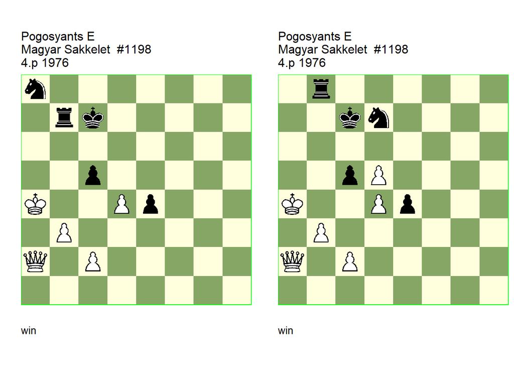

GBR: +1303.32a4c7 U3 FEN: n7/1rk5/8/2p5/K2Pp3/1P6/Q1P5/8 w - - 0 1

Magyar Sakkelet/5 (EG#03298). U3: Ricci=J HHdbIV#43545 2-12-2007 U3: Garcia=M HHdbV#38778 6-2-2009. **1. Qb1!** (1. Qb2? Nb6+ 2. Kb5 Nd7+ 3. Ka5 Ra7+ 4. Kb5 Rb7+ 5. Kc4 Nb6+ 6. Kb5 (6. Kxc5 Na4+ 7. bxa4 Rxb2) 6… Nd7+) **1… Nb6+ 2. Kb5!** (2. Ka3? Nc4+ 3. bxc4 Rxb1) **2… Nd5+!** (2… Nd7+! **cook** JR 3. Kc4 Rb4+ 4. Kc3 Rxd4) (2… cxd4! **cook** MG 3. Qh1 Nd7+ 4. Kc4 d3 5. Qxe4 dxc2 6. Qxc2 Rb6) **3. Kxc5!** (3. Kc4? Kc6) **3… Rb5+! 4. Kc4 Kc6!** (4… Kd6 5. c3!) **5. b4!** (5. c3? Ne3#) (5. Qe1? Rb4+ 6. Qxb4 Ne3+ 7. Kc3 Nd5+) **5… Rxb4+ 6. Qxb4 Nxb4 7. Kxb4 Kd5** (7… Kd6 8. c4!) (7… e3 8. Kc3 e2 9. Kd2 Kd5 10. c3) **8. Kc3 e3 9. Kd3 e2 10. c4+! 1-0**.

GBR: +1303.42a4c7 (c) U2 FEN: 1r6/2kn4/8/2pP4/K2Pp3/1P6/Q1P5/8 w - - 0 1

Magyar Sakkelet/5. correction: Garcia=M Estudios Artisticos de Ajedrez - VIII-83 2012. U2: Neuenschwander=B beatochess 08/09/2025.. **1. Qb1!** (1. Qb2? Nb6+ 2. Kb5 Nd7+ 3. Ka5 Ra8+ 4. Kb5 Rb8+ 5. Kc4 Nb6+ 6. Kb5 (6. Kxc5 Na4+ 7. bxa4 Rxb2) 6… Nd7+) **1… Nb6+ 2. Kb5!** (2. Ka3? Nc4+ 3. bxc4 Rxb1) **2… Nxd5+** (2… Nd7+ 3. Kc4 Rb4+ 4. Kc3 Rxd4 5. Qh1 Kd6 6. Qh7 Ne5 7. Qh6+ Kxd5 8. Kb2 Nf3 9. Qf6 Rd2 10. Kc1 c4 11. b4 Rg2 12. Qe7) (2… Nd7+! **cook** **BN** ? 3. Kc4 Rb4+ 4. Kc3 Rxd4 5. Qh1 Rxd5 6. Qxe4 Rd4 +=) **3. Kxc5!** (3. Kc4? Kc6) **3… Rb5+! 4. Kc4** (4. Kxb5? Nc3+ 5. Kc4 Nxb1) **4… Kc6!** (4… Kd6 5. c3!) **5. b4!** (5. c3? Ne3#) (5. Qe1? Rb4+ 6. Qxb4 Ne3+ 7. Kc3 Nd5+ 8. Kc4 Ne3+) **5… Rxb4+ 6. Qxb4 Nxb4 7. Kxb4 Kd5** (7… Kd6 8. c4!) (7… e3 8. Kc3 e2 9. Kd2 Kd5 10. c3) **8. Kc3 e3 9. Kd3 e2 10. c4+! 1-0**.

### Kotov & Mitrofanov =0430.32h1f1 (1976). Comment

Date: September 4, 2025

File: Kotov1976a.pgn

Nunn’s claim that **1. c5** draws seems incorrect, which makes the correction unnecessary.

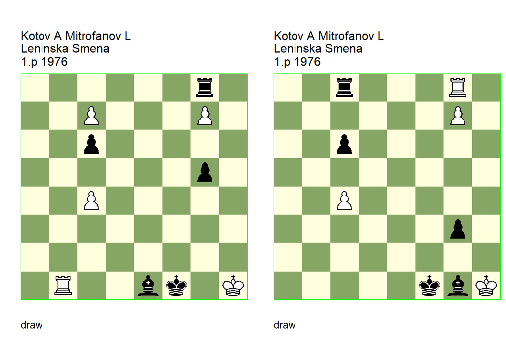

GBR: =0430.32h1f1 FEN: 6r1/2P3P1/2p5/6p1/2P5/8/8/1R2bk1K w - - 0 1

(EG#03259). U1: Nunn=J EG=61 7/1980. Commnet: Neuenschwander=B beatochess 04/09/2025. **1. Rb7!** (1. c5! **cook** JN 1… g4 (1… Rxg7 2. Rxe1+) 2. Rb2 g3 (2… Rc8 3. Rb8 g3 4. g8=Q) (2… Re8 3. Rg2! (3. Rb8? Re3 4. Rh8 Rg3 5. c8=Q Rg1+ 6. Kh2 Bg3#) ) (2… Bd2 3. Rb8 Rxg7 4. Rf8+) (2… Bf2 3. Rb1+ Be1 4. Rb2) 3. c8=Q! Rxc8 4. Rg2 Bc3 (4… Bf2 5. Rxg3 Rg8 6. Rg6) 5. Rxg3 Bxg7 6. Rg1+ Kf2 7. Rg2+ Ke3 8. Rxg7 Kd4 9. Kg2 Kxc5 10. Kf3 Re8 (10… Kb4! wins **BN** 11. Ke3 Kc3 -+) 11. Rg1) (1. Rb8? Rxg7 2. Rh8 Rxc7) **1… g4** (1… Rxg7 2. c8=Q) **2. c8=Q Rxc8 3. Rf7+ Bf2 4. Rf8 g3 5. g8=Q Rxf8 6. c5! Rf7** (6… Rxg8) **7. Qg7!** (7. Qg6? Rh7+ 8. Qxh7 g2+) **7… Rf6 8. Qg6 Rf5 9. Qg5 Rf4** (9… Rxc5 **main** 10. Qd5 cxd5 (10… Rxd5) ) **10. Qg4 Rxg4 1/2-1/2**.

GBR: =0430.22h1f1 (c) FEN: 2r3R1/6P1/2p5/8/2P5/6p1/8/5kbK w - - 0 1

correction: Kotov=A Shakhmaty v SSSR/4 1977. **1. Rf8+! Bf2 2. g8=Q Rxf8 3. c5! Rf7!** (3… Rxg8) **4. Qg7!** (4. Qg6? Rh7+ 5. Qxh7 g2+) **4… Rf6! 5. Qg6! Rf5! 6. Qg5! Rf4! 7. Qg4! Rxg4 1/2-1/2**.

### Frolovsky +0450.12c5a6 (1976). Correction

Date: September 1, 2025

File: Frolovsky1976a.pgn

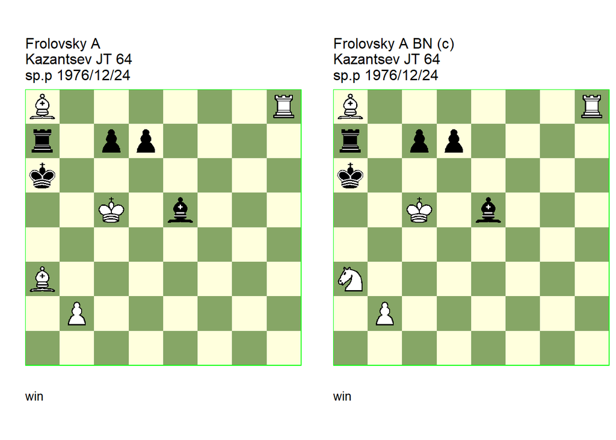

GBR: +0450.12c5a6 U2 FEN: B6R/r1pp4/k7/2K1b3/8/B7/1P6/8 w - - 0 1

64=52(443) (EG#03224). U2: Garcia=M HHdbV#38925 6-2-2009. **1. Rb8! Bd6+ 2. Kd5!** (2. Kc4! **cook** MG 2… Bxa3 3. bxa3 c6 4. Kb4 Rc7 5. a4 Ra7 6. a5 Rc7) **2… Bxa3 3. Bc6! dxc6+** (3… Ka5 4. Rb5+ Ka6 5. b4 Bxb4 6. Rxb4 Ka5 7. Rb5+ Ka4 8. Rb1+ dxc6+ 9. Kc4 Ka5 10. Kc5 Ka6 11. Kxc6) **4. Kxc6 Bc5! 5. b3!** (5. b4? Bb6) **5… Bb6 6. b4! Be3 7. Rb5 Bb6 8. Ra5+! Bxa5 9. b5# 1-0**.

correction: Neuenschwander=B beatochess 01/09/2025 **1. Rb8! Bd6+ 2. Kd5!** ( 2. Kc4? c6! (2… Bxa3? 3. bxa3 c6 4. Kb4 Rc7 5. a4 Ra7 6. a5) ) **2… Bxa3 3. Bc6! dxc6+** (3… Ka5 4. Rb5+ Ka6 5. b4 Bxb4 6. Rxb4 Ka5 7. Rb5+ Ka4 8. Rb1+ dxc6+ 9. Kc4 Ka5 10. Kc5 Ka6 11. Kxc6) **4. Kxc6 Bc5! 5. b3!** (5. b4? Bb6) **5… Bb6 6. b4! Be3 7. Rb5 Bb6 8. Ra5+! Bxa5 9. b5# 1-0**.

### Kuznetsov AG & Rivkin =0407.21b5f7 (1979). Cook

Date: August 29, 2025

File: Kuznetsov1979a.pgn

**5… Rg4** cooks the study.

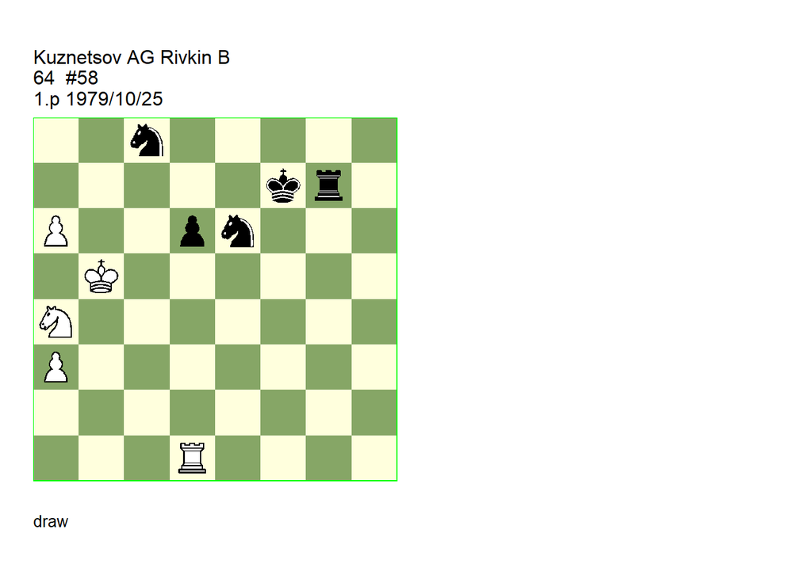

GBR: =0407.21b5f7 U3 FEN: 2n5/5kr1/P2pn3/1K6/N7/P7/8/3R4 w - - 0 1

64=43(590) (EG#04660). Neuenschwander=B beatochess 29/08/2025. **1. a7!** (1. Rc1? Na7+ 2. Kb6 Ke8 3. Re1 Re7) **1… Nxa7+ 2. Ka6! Nc8 3. Kb7 Rg8 4. Rf1+! Ke7** (4… Kg6 5. Nc3! Ne7 6. Ne4! Nc5+ 7. Nxc5 dxc5 8. Rg1+ Kf7 9. Rxg8 Kxg8 10. a4 c4 11. a5 c3 12. a6 Nc6 13. Kxc6 c2 14. a7 c1=Q+ 15. Kb7) **5. Rc1 Kd7** (5… Rg4! **cook** **BN** ) **6. Rxc8! Nd8+! 7. Ka8!** (7. Kb8? Nc6+ 8. Kb7 Na5+) (7. Rxd8+? Kxd8 8. Nc3 Rg2! 9. a4 Rb2+ 10. Nb5 Kd7 11. Kb6! Ke6 12. a5 Kd5 13. a6 Kc4) **7… Kxc8 8. Nb6+ Kc7 9. Nd5+ Kd7!** (9… Kc6 10. Ne7+ Kb5 11. Nxg8 d5 12. Nf6 d4 13. Ne4) **10. Nf6+ Ke6! 11. Nxg8 Nf7! 12. a4 d5 13. a5! d4 14. Nh6!** (14. a6? d3 15. Kb8 Nd8! 16. Kc7 Nc6! 17. Kxc6 d2 18. a7 d1=Q 19. a8=Q Qd5+) **14… Nxh6 15. a6 Nf7 16. Kb8 Nd8 17. Kc7 1/2-1/2**.

### Bazlov +0174.01F6e1 (1979). Correct?

Date: August 26, 2025

File: Bazlov1979a.pgn

The study seems correct because Black has **2… Nf3+** in the line **1. Bb3+**.

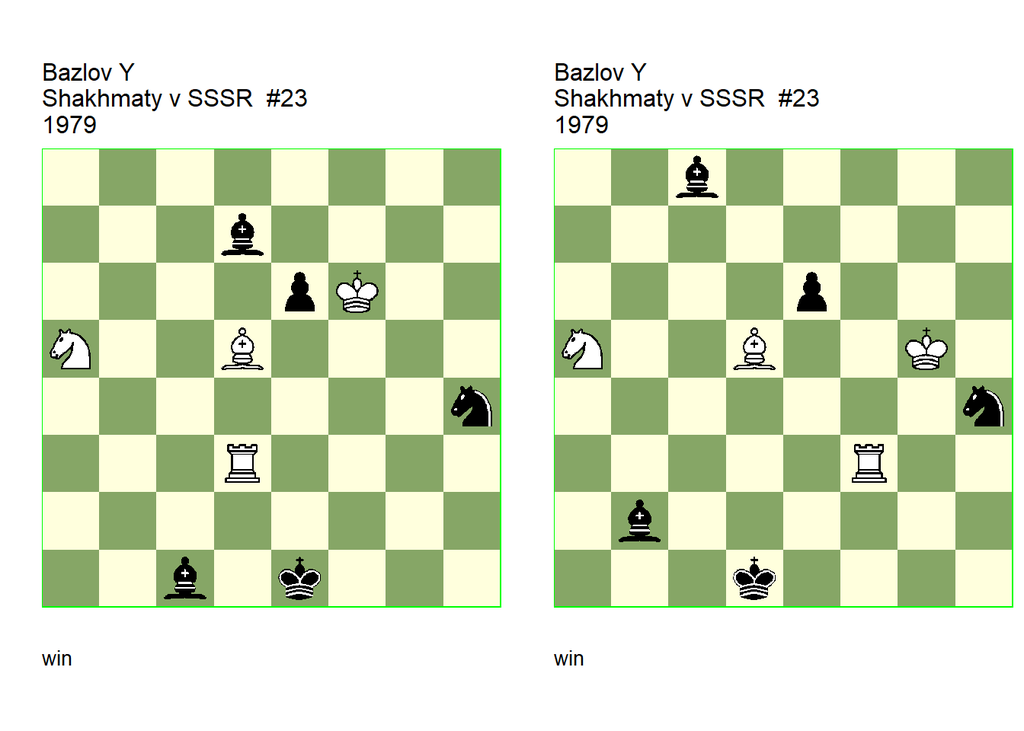

GBR: +0174.01f6e1 U2 FEN: 8/3b4/4pK2/N2B4/7n/3R4/8/2b1k3 w - - 0 1

Shakhmaty v SSSR/6 (EG#04534). U2: Makletsov=Y Shakhmaty v SSSR/2 1982. **1. Be4!** (1. Bb3? Bd2 2. Nc4 Bb5!) **1… Bc8** (1… Bb5 2. Rb3! (2. Rh3? Nf5 3. Rh1+ Bf1) 2… Ba4 (2… Be2 3. Rb1 Kd2 4. Nb3+ Ke3 5. Nxc1) (2… Ba6 3. Rb1 Kd2 4. Nb3+ Ke3 5. Rxc1 Kxe4 6. Nc5+) ) **2. Rh3 Bb2+** (2… Nf5 3. Rh1+ Kd2 4. Nb3+) **3. Kg5 Nf5 4. Rh1+ Kd2 5. Rh2+** (5. Bxf5! **cook** YM 5… exf5 6. Nc4+ Kc3 7. Nb6 Bb7 (7… Be6 8. Na4+ Kb3 9. Nc5+) (7… Ba6 8. Na4+ Kb3 9. Nc5+) 8. Na4+ Kb4 9. Rh4+ Kb3 10. Nxb2 Kxb2 11. Rb4+) **5… Kc3 6. Rc2+ Kb4 7. Bxf5 exf5 8. Nb7! Bc3 9. Nc5! Kc4** (9… f4 10. Ne4) **10. Rc1!** (10. Na4? Ba6 11. Nxc3 (11. Rxc3+ Kb4 12. Rc6 Bb5) 11… Kb3 12. Rc1 Kb2) (10. Kh5? f4! 11. Ne4 Bf5) (10. Kf4?) **10… Kd4** (10… Kb4 11. Kh5 f4 (11… Bd2 12. Nd3+) (11… Kc4 12. Na4) 12. Ne4) **11. Kh4** (11. Kh5? f4! 12. Na4 f3 13. Nxc3 f2 14. Ne2+ Ke3 15. Ng3 Kf3 16. Kh4 Bd7!) **1-0**.

GBR: +0174.01g5d1 (c) FEN: 2b5/8/4p3/N2B2K1/7n/5R2/1b6/3k4 w - - 0 1

Shakhmaty v SSSR/6 21/23.p USSR overall champ XV 1979-1980 64 Shakhmatnoye Obozrenye=20(691) 64 Shakhmatnoye Obozrenye/10 1983. U1: Van, der, Heijden=H HHdbVI 13-11-2018. Comment: Neuenschwander=B beatochess 26/08/2025. **1. Rf1+** ( 1. Bb3+! **cook** HH 1… Ke2 2. Rf8 Bd7 (2… Nf3+! = comment **BN** ) 3. Kxh4) **1… Kd2 2. Rf2+ Kc3 3. Be4 Nf5 4. Rc2+ Kb4 5. Bxf5 exf5 6. Nb7 Bc3 7. Nc5! Kc4 8. Rc1 Kd4 9. Kh4 f4 10. Na4 1-0**.

### Kopac +3111.27g2g5 (1979). Cook

Date: August 25, 2025

File: Kopac1979a.pgn

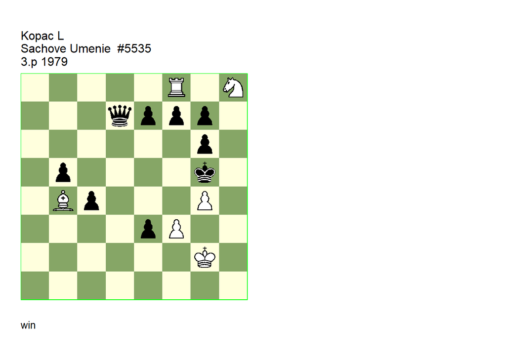

GBR: +3111.27g2g5 U2 FEN: 5R1N/3qppp1/6p1/1p4k1/1Bp3P1/4pP2/6K1/8 w - - 0 1

Sachove Umenie/12 (EG#04512). U2: Neuenschwander=B beatochess 25/08/2025. **1. Nxf7+** (1. Rd8? Qa7 2. Nxf7+ Kf6 3. Rf8 e6) **1… Kf4** (1… Kf6 2. Bc3+ Ke6 3. Rd8 Qa7 4. Ng5#) **2. Rd8** (2. Nh8+! **cook** **BN** 2… Ke5 (2… Kg5 3. Kg3 e5 4. Bc5 Kh6 5. Bxe3+ g5 6. Nf7+) 3. Nxg6+ Kd4 (3… Ke6 4. Rf5) (3… Kd5 4. Rf5+ e5 5. Rxe5+ Kc6 6. Ne7+ Kb7 7. Nd5) 4. Rf4+ Kd5 5. Re4) **2… Qa7 3. Ba5** (3. Bc3? Qa2+ 4. Kh3 Kxf3) **3… e5 4. Rf8 e4 5. Nd8+ Ke5** (5… Kg5 6. Ne6+ Kh4 (6… Kh6 7. Rh8#) 7. Rh8#) **6. Nc6+ 1-0**.

### Joitsa =0621.00h2g4 (1981). Cook

Date: August 22, 2025

File: Joitsa1981b.pgn

According to tablebase **1… Kf3! 2. Bh5+ Kf4!** cooks the study.

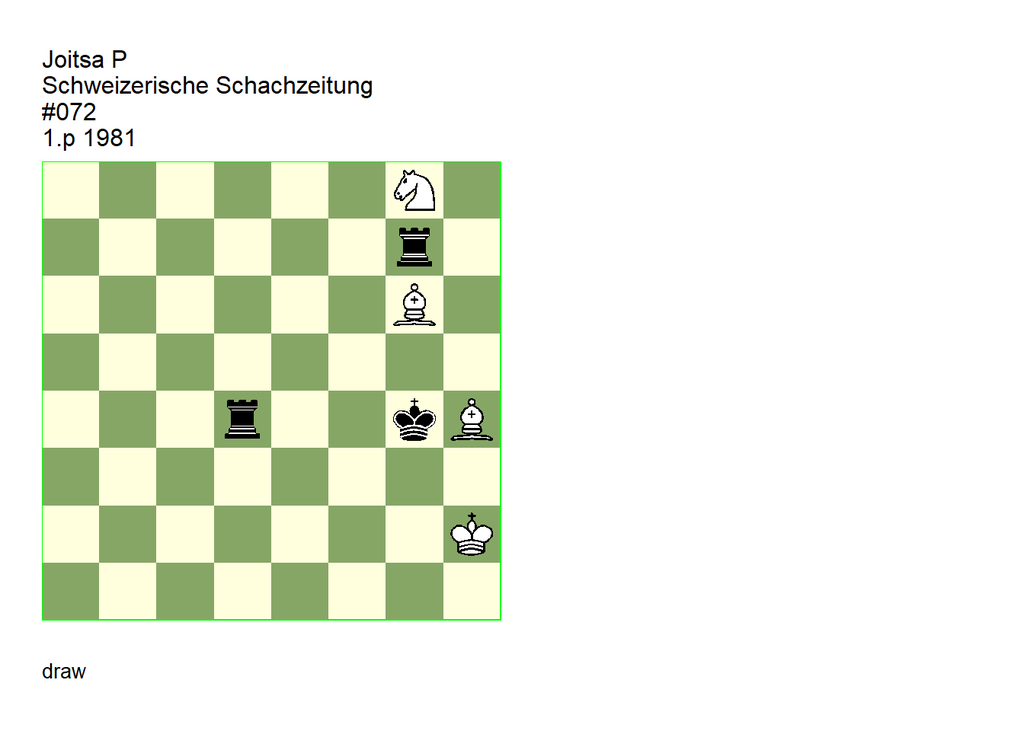

GBR: =0621.00h2g4 U3 FEN: 6N1/6r1/6B1/8/3r2kB/8/7K/8 w - - 0 1

Schweizerische Schachzeitung=2 Schweizerische Schachzeitung/2 1982 (EG#08186). U3: Neuenschwander=B beatochess 22/08/2025. **1. Nh6+!** (1. Bf6? Rd2+ 2. Kg1 Rxg6) (1. Bb1? Rd2+) (1. Be8? Rxg8) (1. Ne7? Rd2+ 2. Kg1 Kxh4 3. Nf5+ Kg5 4. Nxg7 Kxg6 5. Ne6 Kf5 6. Nc5 Ke5 7. Nb3 Rd3 8. Nc5 Rc3 9. Na4 Rc2) **1… Kf4!** (1… Kxh4 2. Nf5+) (1… Kf3 2. Bh5+ Ke4 (2… Kf4! **cook** **BN** (TB) ) 3. Ng4 Rh7 4. Bg6+) **2. Bg3+!** (2. Bh5? Rh7) (2. Bb1? Rd2+ 3. Kh3 Rgg2!) (2. Be8? Rh7) (2. Bf5? Rd6) **2… Kg5** (2… Kf3 3. Nf5 Rd2+ 4. Kh3 Rxg6 5. Nh4+) **3. Nf5! Rd2+ 4. Kh3! Rxg6 5. Nh4! Rf6** (5… Rh6 **main** 6. Bf4+! Kxf4) **6. Nf3+! Rxf3 1/2-1/2**.

### Petrenj =0013.51h8f8 (1982). Cook

Date: August 18, 2025

File: Petrenj1982b.pgn

**3. Bc3!** cooks the study.

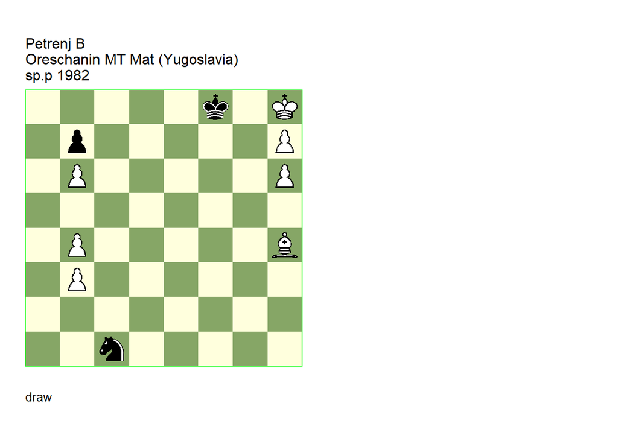

GBR: =0013.51h8f8 U2 FEN: 5k1K/1p5P/1P5P/8/1P5B/1P6/8/2n5 w - - 0 1

Mat (Yugoslavia)=11-12 Mat (Yugoslavia)/11-12 (EG#08087). U2: Neuenschwander=B beatochess 18/08/2025. **1. Bg3** (1. Be7+? Kf7 2. Bd6 Ne2 3. Be5 Ng1 4. Bd4 Nf3 5. Bf6 Nh2 6. Be5 Ng4 7. Bd4 Nxh6 8. Be3 Nf5 9. Bg5 Kf8 10. b5 Kf7 11. b4 Nd4 12. Bf4 Nxb5 13. Be5 Na3 14. Bd4 Nc2 15. Bc5 Ne1 16. Be7 Nd3 17. Bd6 Nb2 18. Be5 Nc4 19. Bd4 Nd6 20. Be3 Nf5 21. Bg5 Kf8 22. b5 Kf7) **1… Ne2** (1… Nd3 2. Bd6+ Kf7 3. b5 Nf2 4. Bb4 Ne4 5. Ba5) **2. Be5 Ng1 3. Bd4** (3. Bc3! **cook** **BN** 3… Nh3 4. Bd2 Nf2 5. b5 Ng4 6. Bb4+ Kf7 7. Bc3 Nxh6 8. Ba5 Kf8 9. Bb4+ Kf7 10. Ba5 Nf5 11. b4) **3… Nf3 4. Bf6 Kf7 5. b5 Nh2 6. Be5 Ng4 7. Bc3 Nxh6 8. Ba5 Nf5 9. b4 Kf8 1/2-1/2**.

### Nadareishvili & Neidze =0110.02d4g3 (1986). Cook/dual

Date: August 17, 2025

File: Nadareishvili1986a.pgn

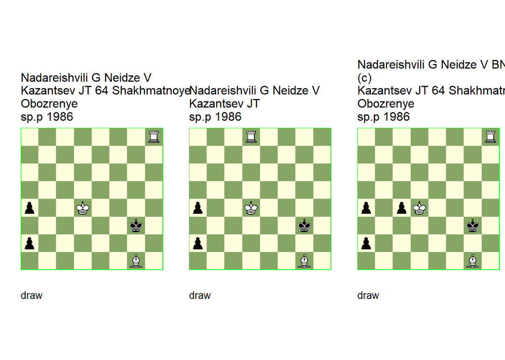

GBR: =0110.02d4g3 U2 FEN: 7R/8/8/8/p2K4/6k1/p7/6B1 w - - 0 1

64 Shakhmatnoye Obozrenye=3(770) 64 Shakhmatnoye Obozrenye/2 1987 21/34.p USSR overall champ XVIII 1985-1986 Bulletin Central Chess Club USSR=19(461) Bulletin Central Chess Club USSR/7 1989. U2: Neuenschwander=B beatochess 17/08/2025. **1. Rg8+** (1. Bh2+? Kg2 2. Rg8+ Kxh2 3. Rh8+ Kg2 4. Rg8+ Kf2 5. Rf8+ Ke2 6. Re8+ Kd2) (1. Bf2+? Kg2) **1… Kh3!** (1… Kh4 2. Bf2+) (1… Kf3 2. Rf8+ Ke2 3. Rf2+) **2. Rh8+ Kg4 3. Rg8+ Kh5 4. Rh8+ Kg6 5. Rg8+ Kf7!** (5… Kh7 6. Rh8+ Kxh8 7. Kc4 a1=Q 8. Bd4+ Qxd4+ 9. Kxd4) **6. Rg7+! Ke6** (6… Kxg7 7. Kc4) (6… Kf6 7. Kc4) (6… Kf8 7. Kc4 a1=Q 8. Bc5+ Ke8 9. Re7+ Kd8 10. Re3) **7. Rg6+ Kd7** ( 7… Kf5 8. Rf6+!) **8. Rg7+ Kc6 9. Rg6+ Kb5!** (9… Kb7 10. Rg7+ Ka6 11. Kc4! (11. Ra7+? Kb5 12. Rb7+ Kc6 13. Rb6+ Kc7) 11… a1=Q 12. Ra7#) **10. Rb6+!** (10. Rg5+? Kb4) **10… Ka5** (10… Kxb6 11. Kc3+ Kb5 12. Kb2) **11. Kc4!** (11. Kc5! **cook** **BN** 11… a1=Q 12. Rb5+ Ka6 13. Rb6+ Ka7 14. Bd4) **11… a1=Q 12. Rb5+ Ka6 13. Rb6+ Ka5 14. Rb5+ 1/2-1/2**.

GBR: =0110.02d4g3 (v) U1 FEN: 3R4/8/8/8/p2K4/6k1/p7/6B1 w - - 0 1

64 Shakhmatnoye Obozrenye=3(770) 64 Shakhmatnoye Obozrenye/2 1987 (EG#08073). U1: Garcia=M HHdbIV#55233 19-1-2007 U1: Van, der, Heijden=H HHdbIV#55233 30-8-2008. **1. Rg8+** (1. Bh2+? Kxh2 2. Rh8+ Kg2 3. Rg8+ Kf2 4. Rf8+ Ke2 5. Re8+ Kd2) (1. Ke4! **cook** MG 1… a1=Q 2. Rd3+ Kg4 3. Bc5) (1. Kc4! **cook** HH ) **1… Kh3** (1… Kh4 2. Bf2+ Kh3 3. Rg1) (1… Kf3 2. Rf8+ Ke2 3. Rf2+) **2. Rh8+ Kg4 3. Rg8+ Kh5 4. Rh8+ Kg6 5. Rg8+ Kf7** (5… Kh7 6. Rh8+ Kxh8 7. Kc4 a1=Q 8. Bd4+) **6. Rg7+! Ke6** (6… Kxg7 7. Kc4) (6… Kf8 7. Kc4 a1=Q 8. Bc5+! Ke8 9. Re7+ Kd8 10. Re3) **7. Rg6+ Kd7** (7… Kf5 8. Rf6+!) **8. Rg7+ Kc6 9. Rg6+ Kb5!** (9… Kb7 10. Rg7+ Ka6 11. Kc4! (11. Ra7+? Kb5 12. Rb7+ Kc6 13. Rb6+ Kc7) 11… a1=Q 12. Ra7#) **10. Rb6+! Ka5** (10… Kxb6 11. Kc3+ Kb5 12. Kb2) **11. Kc4! a1=Q 12. Rb5+ Ka6 13. Rb6+ Ka5 14. Rb5+ 1/2-1/2**.

GBR: =0110.03d4g3 (c) FEN: 7R/8/8/8/p1pK4/6k1/p7/6B1 w - - 0 1

corrrection: Neuenschwander=B beatochess 17/08/2025. **1. Rg8+ Kh3 2. Rh8+ Kg4 3. Rg8+ Kh5 4. Rh8+ Kg6 5. Rg8+ Kf7 6. Rg7+ Ke6 7. Rg6+ Kd7 8. Rg7+ Kc6 9. Rg6+ Kb5 10. Rb6+ Ka5 11. Kxc4 a1=Q 12. Rb5+ Ka6 13. Rb6+ Ka5 14. Rb5+ 1/2-1/2**.

### Volkov +0440.11b8d8 (1986). Cook

Date: August 17, 2025

File: Volkov1986a.pgn

The version/correction is also not correct due to **5… Bd8!**.

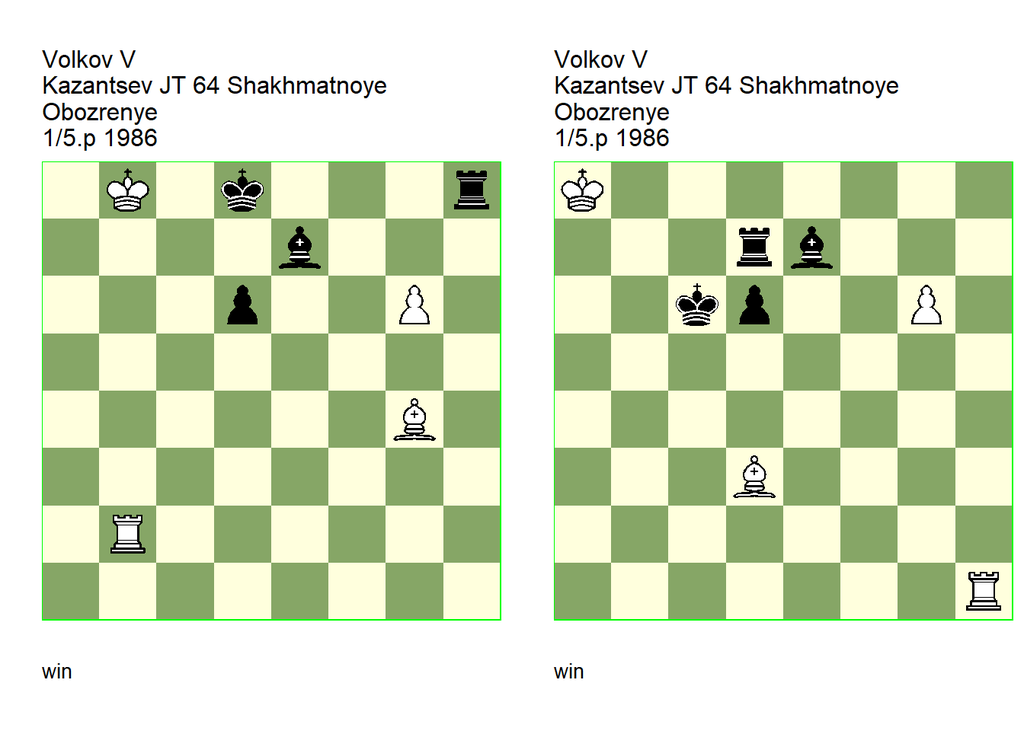

GBR: +0440.11b8d8 U3 FEN: 1K1k3r/4b3/3p2P1/8/6B1/8/1R6/8 w - - 0 1

64 Shakhmatnoye Obozrenye=3(770) 64 Shakhmatnoye Obozrenye/2 1987 (EG#08066). U3: Garcia=M HHdbV#27227 23-9-2011. **1. g7 Rg8 2. Ka7 Ke8!** (2… Kc7 3. Rb7+ Kc6 4. Rxe7 d5 5. Be6 Kd6 6. Bxg8 Kxe7 7. Bxd5) (2… Bf6 3. Rb8+ Ke7 4. Rxg8 Kf7 5. Be6+ Kxe6 6. Re8+) (2… Bf8! **cook** MG ) **3. Rb8+ Kf7 4. Be6+! Kxe6 5. Rxg8 Kf7 6. Re8! 1-0**.

GBR: +0440.11a8c6 (v) U3 FEN: K7/3rb3/2kp2P1/8/8/3B4/8/7R w - - 0 1

64 Shakhmatnoye Obozrenye=3(770) 64 Shakhmatnoye Obozrenye/2 1987 . version: Volkov=V 64 Shakhmatnoye Obozrenye=18(785) 9/1987. U3:Neuenschwander=B beatochess 17/08/2025. **1. g7 Rd8+ 2. Ka7 Rg8 3. Rc1+ Kd7 4. Bf5+ Ke8 5. Rc8+ Kf7** (5… Bd8! **cook** **BN** ) **6. Be6+! Kxe6 7. Rxg8 Kf7 8. Re8! 1-0**.

### Dobrescu =0113.11b2d8 (1986). Cook

Date: August 16, 2025

File: Dobrescu1986d.pgn

According to tablebase **5… e1Q** cooks the study.

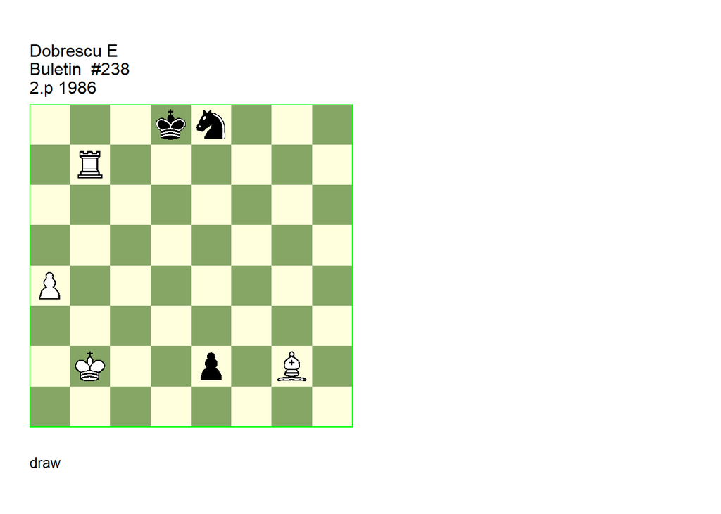

GBR: =0113.11b2d8 U3 FEN: 3kn3/1R6/8/8/P7/8/1K2p1B1/8 w - - 0 1

Buletin Problemistic=46 Buletin Problemistic/7-12 (EG#08043). U3: Neuenschwander=B beatochess 16/08/2025. **1. Bh3** (1. Rb8+? Ke7 2. Rb7+ Kf8 3. Bd5 Nd6) **1… Nc7** (1… Nf6 2. Rb8+ Kc7 (2… Ke7 3. Rb6) 3. Rc8+) **2. Rb8+ Ke7 3. Rb7** (3. Rc8? Kd6 4. Rd8+ Kc6 5. Bg2+ Kb6 6. Rb8+ Ka5 7. Rc8 e1=Q 8. Rxc7 Qe5+ 9. Rc3 Kb4) **3… Kd6 4. Rb6+ Kc5** (4… Ke5 5. Rc6 e1=Q 6. Rxc7 Qb4+ 7. Kc2 Qxa4+ 8. Kb2 Qb4+ 9. Kc2 Qe4+ 10. Kb2 Qb4+ 11. Kc2 Qa4+ 12. Kb2 Qb5+ 13. Kc2 Qe2+ 14. Kb3 Qd1+ 15. Kb2) **5. Rb7 Nd5** (5… Kc6 6. Bg2+ Kd6 (6… Kd7 7. Bh3+ Kd6 (7… Kd8 8. Rb8+) 8. Rb6+) 7. Rb6+ Kd7 (7… Ke5 8. Rb4) 8. Bh3+ Kd8 (8… Ke7 9. Rc6) 9. Rd6+ Ke8 10. Rc6 e1=Q 11. Rxc7) (5… e1=Q! **cook** **BN** (TB) 6. Rxc7+ Kb4 7. Rb7+ (7. Rc2 Qe5+ 8. Ka2 Qd5+ 9. Kb2 Qb3+) 7… Kxa4 8. Ra7+ Kb4 9. Rb7+ Ka5 10. Rb3 Qd2+) **6. Bg2!** (6. Be6? Nf4 7. Rc7+ Kd6 8. Rc1 Nd3+ 9. Kc2 Nxc1 10. Kd2 Kxe6) (6. Rb5+? Kd6 7. Bg2 Ne3) **6… Ne3 7. Rc7+ Kb4** ( 7… Kb6 8. Rc1 Nd1+ 9. Kc2) **8. Rc1!** (8. Rb7+? Ka5! 9. Ra7+ Kb6 10. Rb7+ Ka6) **8… Nd1+ 9. Kc2 e1=Q 10. Rb1+! Kc4 11. Bd5+! 1/2-1/2**.

### Nestorescu +0111.34f4b2 (1986). Correct?

Date: August 16, 2025

File: Nestorescu1986b.pgn

The study may be correct. My Stockfish does not consider White’s advantage significant in the two cooks given by John Nunn.

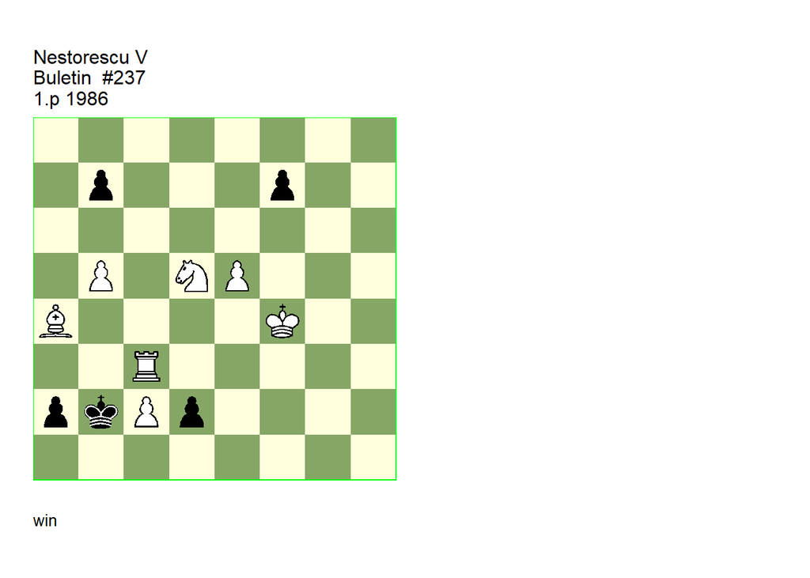

GBR: +0111.34f4b2 U2 FEN: 8/1p3p2/8/1P1NP3/B4K2/2R5/pkPp4/8 w - - 0 1

Buletin Problemistic=46 Buletin Problemistic/7-12 (EG#08042). U2: Nunn=J EG=159-162 12/2005. **1. Rb3+!** (1. Rd3? a1=Q 2. Nc3 Kc1 3. Ne2+ Kb2 4. Rb3+ Ka2 5. Rd3 Kb2 6. Nc3 Kc1) **1… Kc1 2. Nb4 a1=Q 3. Nd3+ Kd1 4. Rb1+ Qxb1 5. Ke3!** (5. Kf3? Qa1 6. Bb3 Qc3 7. Ke3 b6 8. Kf3 Qxb3 9. cxb3 Kc2 10. Nf2 Kxb3) **5… Qa1 6. Bb3 Qa3** (6… Qc3 7. b6 Qxb3 8. cxb3 Kc2 9. Nf2 Kxb3 10. Kd4 Kb4 11. Kd5) **7. b6!** (7. Kf3 b6 8. Ke3 f5 9. e6 f4+ 10. Kf3 (10. Kf2! **cook** JN 10… Qxb3 11. cxb3 Kc2 12. Ne1+ (12. e7? Kxd3) 12… Kc1 13. e7 d1=Q 14. e8=Q) 10… Qa8+ 11. Kf2 Qf3+! 12. Kxf3) **7… f6 8. e6 f5 9. Kf3** (9. Kf2! **cook** JN 9… Qxb3 10. cxb3 Kc2 11. Ne1+ Kc1 12. e7 d1=Q 13. e8=Q) **9… f4 10. e7 1-0**.

### Hlinka +0413.12d3e8 (1985). Cook

Date: August 15, 2025

File: Hlinka1985b.pgn

In the line **2… Nb8** (intended as a mainline), **9… Kd5** draws.

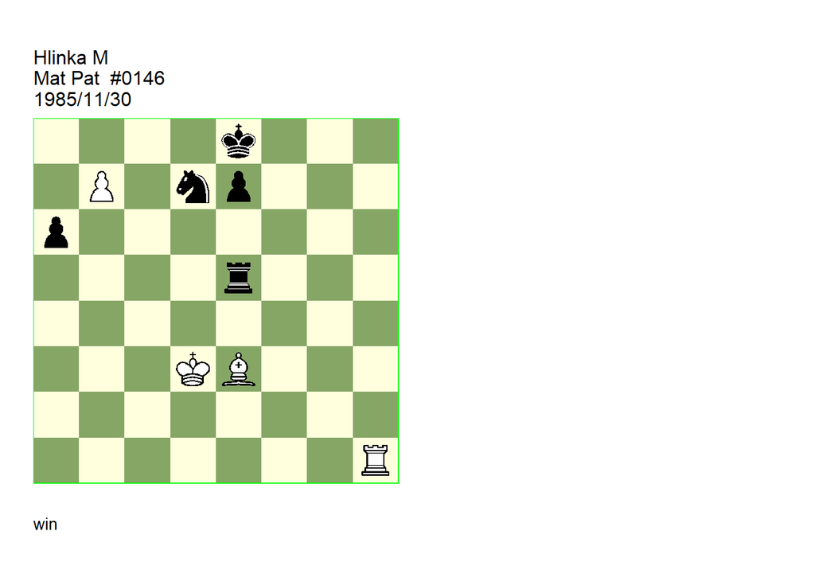

GBR: +0413.12d3e8 U3 FEN: 4k3/1P1np3/p7/4r3/8/3KB3/8/7R w - - 0 1

Mat Pat=6 .p Martin RT 1983-1985 Mat Pat=10 3-1-1987 (EG#08024). U3: Neuenschwander=B beatochess 15/08/2025. **1. Rh8+ Kf7 2. Rd8 Rd5+** (2… Rb5 **main** 3. Rxd7 Ke6 4. Rc7 Kd6 5. Bf4+ e5 6. Bxe5+! Kxe5 7. Rc5+ Rxc5 8. b8=Q+) (2… Nb8 **main** 3. Rxb8 Rb5 4. Kc4 Ke6 5. Bb6! Rxb6 6. Kc5 Rb1 7. Kc6 Rc1+ 8. Kb6 Rb1+ 9. Ka7! Kf5 eg (9… Kd5! **cook** **BN** 10. Rd8+ Kc4 =) 10. Rf8+ Ke4 11. b8=Q Rxb8 12. Rxb8! e5 13. Kxa6 Kd3 14. Rd8+ Kc3 15. Re8! Kd4 16. Kb5 e4 17. Kb4) **3. Kc4!** (3. Bd4? Ne5+) (3. Ke4? Rb5 4. Rxd7 Ke6 5. Rc7 Kd6 6. Bf4+ e5) (3. Kc3? Rb5 4. Rxd7 Ke6 5. Rc7 Kd6 6. Bf4+ e5 7. Bxe5+ Kxe5 8. Rc5+ Rxc5+ 9. Kb4 Rb5+) **3… Rb5 4. Rxd7 Ke6 5. Bb6!** (5. Rc7? Kd6 6. Bf4+ e5 7. Bxe5+ Kxe5 8. Rc5+ Kd6! 9. Rxb5 axb5+! 10. Kxb5 Kc7 11. Ka6 Kb8 12. Kb6) **5… Rxb6 6. Kc5! Rb1 7. Rc7 Rc1+ 8. Kb6 Rb1+ 9. Ka7! 1-0**.

### Katsnelson & Mitrofanov +0530.01c5e8 (1988). Correction

Date: August 15, 2025

File: Katsnelson1988a.pgn

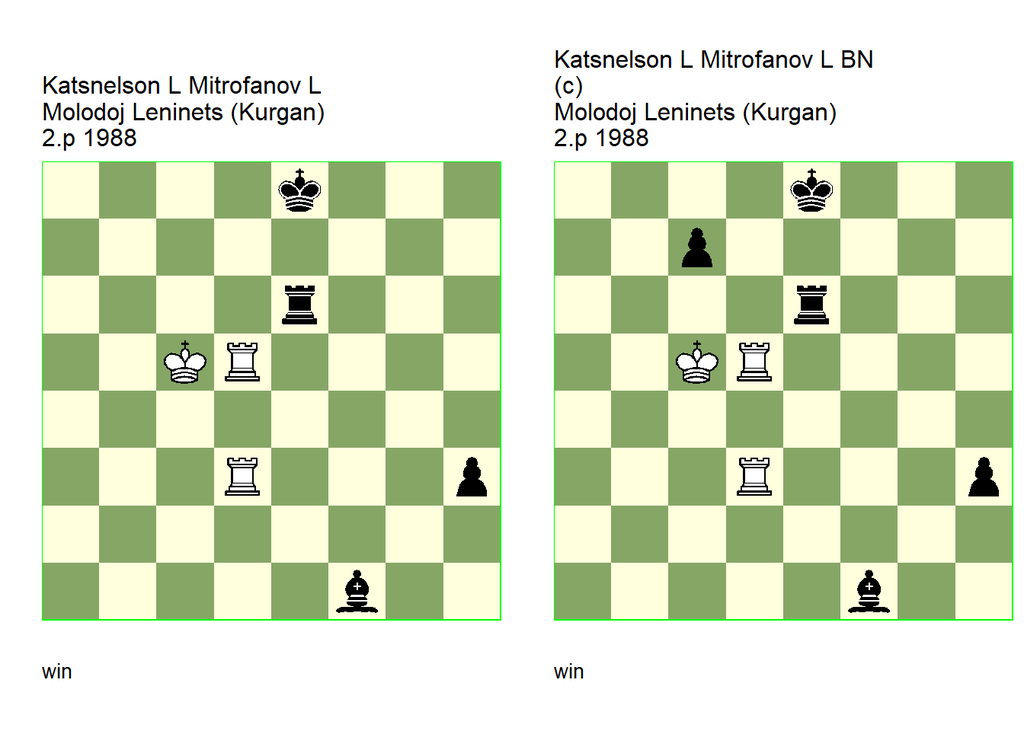

GBR: +0530.01c5e8 U2 FEN: 4k3/8/4r3/2KR4/8/3R3p/8/5b2 w - - 0 1

(EG#08008). U2: Garcia=M HHdbV#25229 24-9-2011. **1. Rd8+ Kf7** (1… Ke7 2. R3d7+ Kf6 3. Rf8+) **2. Rf3+ Ke7** (2… Rf6 3. Rf8+ Kxf8 4. Rxf6+ Kg7 5. Rxf1) **3. Rdf8 Rc6+ 4. Kxc6 Bg2 5. Rf4** (5. Kc5! **cook** MG 5… h2 6. R3f7+ Ke6 7. Rf6+ Ke5 (7… Ke7 8. R8f7+ Ke8 9. Kd6) 8. Rf2 h1=Q 9. Re8#) (5. Rf7+! **cook** MG ) **5… h2 6. Re4+ Kd8 7. Rf8# 1-0**.

GBR: +0530.02c5e8 (c) FEN: 4k3/2p5/4r3/2KR4/8/3R3p/8/5b2 w - - 0 1

correction: Neuenschwander=B beatochess 15/08/2025. **1. Rd8+ Kf7 2. Rf3+ Ke7 3. Rdf8 Rc6+ 4. Kxc6 Bg2 5. Rf4 h2 6. Re4+ Kd8 7. Rf8# 1-0**.

### Makletsov +3540.10a6b8 (1986). Comment

Date: August 13, 2025

File: Makletsov1986a.pgn

**1. Bd6+** is not working: the bishop is taken with check! That is, the original study is correct and the correction unnecessary.

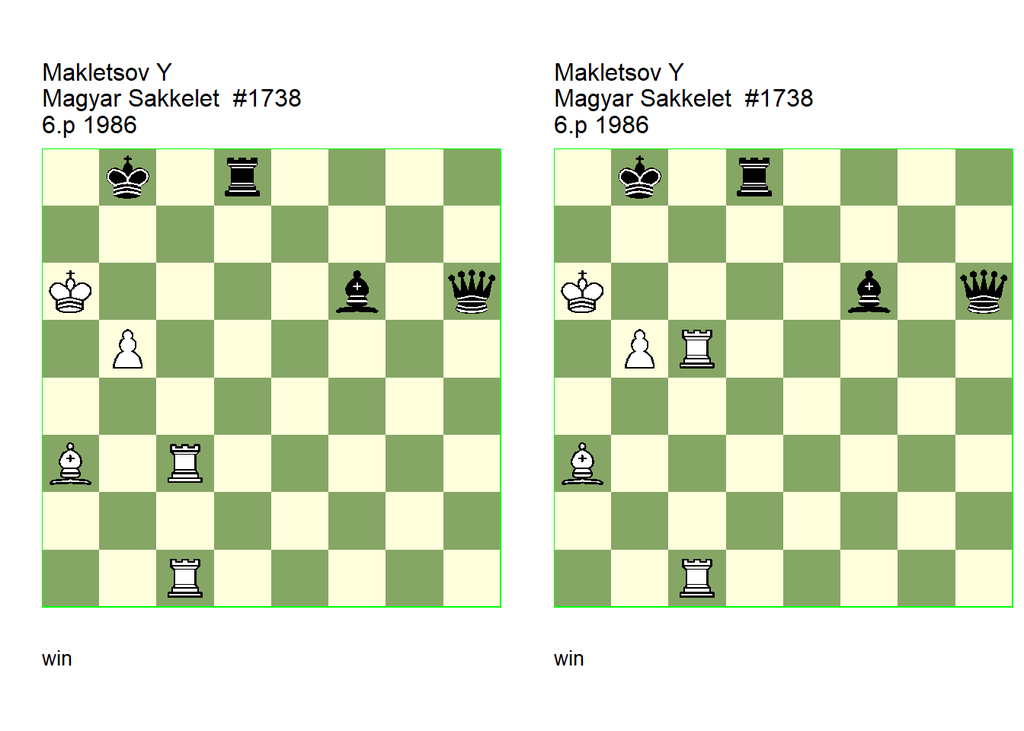

GBR: +3540.10a6b8 U1 FEN: 1k1r4/8/K4b1q/1P6/8/B1R5/8/2R5 w - - 0 1

Magyar Sakkelet/9-10 (EG#07986a). U1: Roycroft=A EG=101 7/1990. Comment: Neuenschwander=B beatochess 13/08/2025. **1. Rc8+!** (1. Bd6+! **cook** AR 1… Ka8 (1… Rxd6+! comment **BN** ) 2. Rc8+ Rxc8 3. Rxc8#) **1… Rxc8 2. Bd6+ Rc7 3. Bxc7+ Ka8 4. b6 Be5** (4… Bc3 **main** 5. Rg1! (5. Rd1? Bd2) ( 5. Rf1? Bg7) 5… Bg7 6. Rxg7 Qg6! 7. Rg8+! (7. Rxg6?) 7… Qxg8 8. b7# ) **5. Bd6! Qxd6** (5… Bxd6 6. b7+ Kb8 7. Rc8#) **6. Rc8+ Qb8 7. b7# 1-0**.

GBR: +3540.10a6b8 (c) FEN: 1k1r4/8/K4b1q/1PR5/8/B7/8/2R5 w - - 0 1

Magyar Sakkelet/9-10 (EG#07986). correction: Roycroft=A EG=101 7/1990. **1. Rc8+! Rxc8 2. Bd6+ Rc7 3. Bxc7+ Ka8 4. b6 Be5** (4… Bc3 **main** 5. Rg1! ( 5. Rd1? Bd2) (5. Rf1? Bg7) 5… Bg7 6. Rxg7 Qg6! 7. Rg8+! (7. Rxg6?) 7… Qxg8 8. b7#) **5. Bd6! Qxd6** (5… Bxd6 6. b7+ Kb8 7. Rc8#) **6. Rc8+ Qb8 7. b7# 1-0**.

### Bogdasaryan =0043.10h6f6 (1986). Dual

Date: August 13, 2025

File: Bogdasaryan1986a.pgn

**3. Bc6** is a dual.

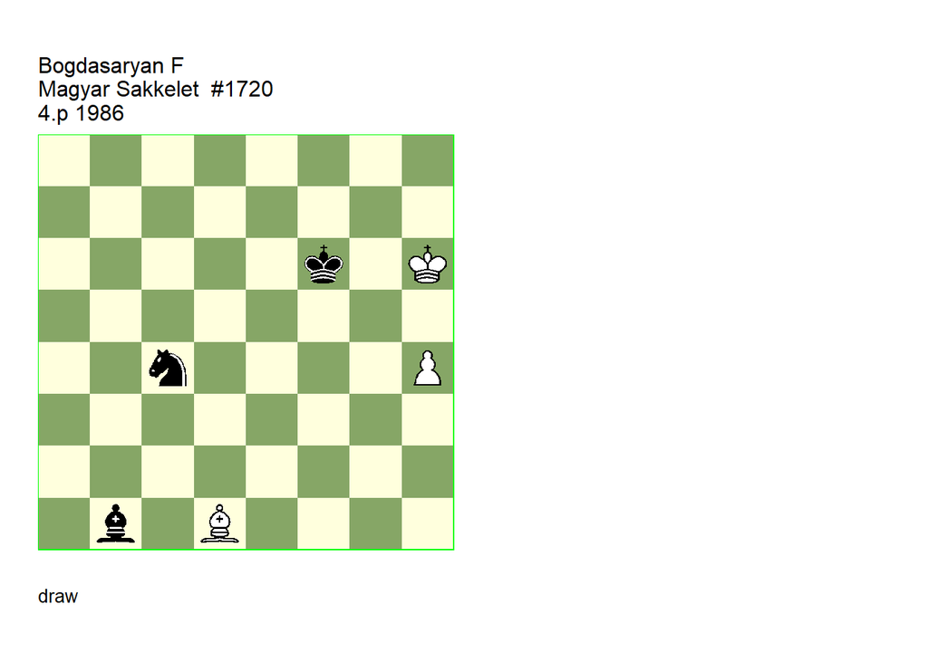

GBR: =0043.10h6f6 (U2) FEN: 8/8/5k1K/8/2n4P/8/8/1b1B4 w - - 0 1

Magyar Sakkelet/5 (EG#07984). (U2): Neuenschwander=B beatochess 13/08/2025. **1. Ba4!** (1. Bb3? Ne5!) (1. Bg4? Nd6!) (1. Be2? Ne3! 2. Bb5 Bc2! 3. Bd7 Nc4! 4. Be8 Nd6 5. h5 Bb3! 6. Bg6 Bg8!) **1… Ne3 2. Bd7 Nc4 3. Ba4!** (3. Be8? Nd6 4. Bh5 Bc2 5. Bg4 Nf7+ 6. Kh5 Bg6#) (3. Bc6! **dual** **BN** ) **3… Ne5** (3… Ne3 **main** 4. Bd7 Bg6 5. Be6 Bc2 6. Bc8 (6. Bh3 or ) 6… Nc4 7. Bd7! Nd6 8. Kh5! Nf7 9. Bf5! Bd1+ 10. Bg4 Ba4 11. Bd7! Bb3 12. Bf5! Bc4 (12… Kxf5) 13. Bd7!) **4. Be8 Ng4+ 5. Kh5 Ne3 6. Bd7! Bc2 7. Be8! Bf5 8. Kh6 Bc2 9. Kh5! Bd3 10. Bd7 Bg6+ 11. Kh6 Nc4 12. h5! Bf7 13. Ba4 Ne5 14. Kh7 Nf3 15. Bc2 Ng5+ 16. Kh6! Bg8 17. Bb3! Bxb3 1/2-1/2**.

Date: August 13, 2025

File: Benko1986a.pgn

**10. Rg8** is not a cook.

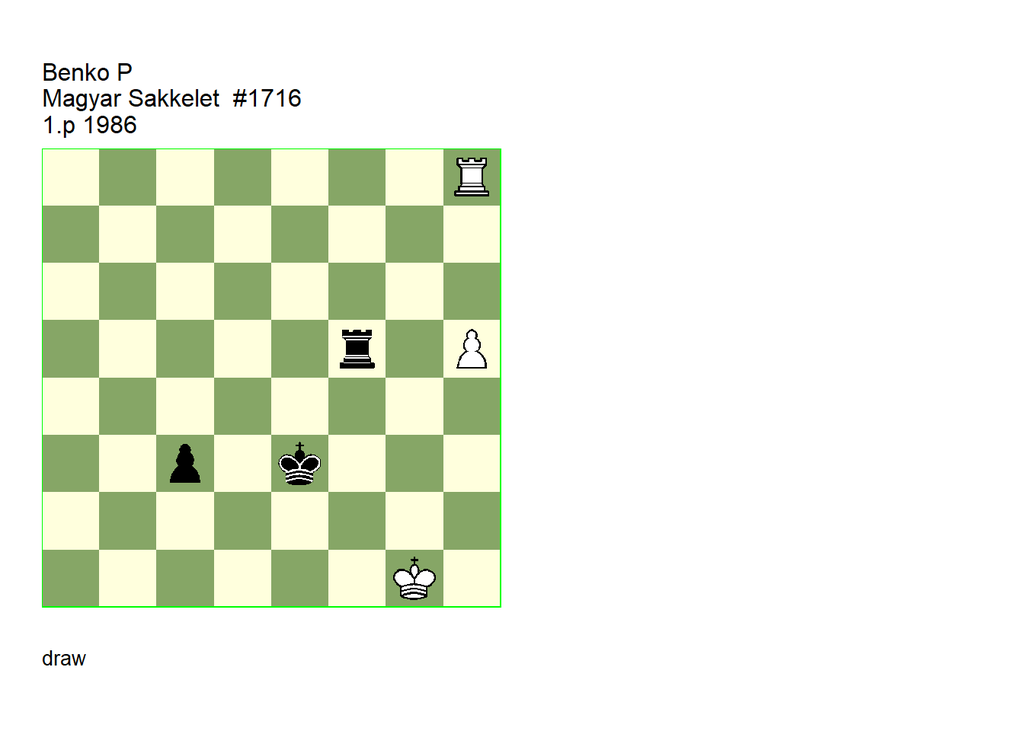

GBR: =0400.11g1e3 U2 FEN: 7R/8/8/5r1P/8/2p1k3/8/6K1 w - - 0 1

Magyar Sakkelet/3 (EG#07981). U2: Van, der, Heijden=H HHdbIII#15341 11-7-2001. Comment: no cook, Neuenschwander=B beatochess 13/08/2025. **1. Rc8** (1. h6? Rg5+! (1… Rc5? 2. Re8+ Kf3 (2… Kd3 3. Rd8+ Kc4 4. h7 c2 5. h8=Q c1=Q+ 6. Kh2!) 3. Rf8+ Kg3 4. Rg8+ Kf4 5. Rf8+ Kg5 6. Rf1! Kxh6 7. Kg2 Kg5 8. Rh1 Kf4 9. Kf2) 2. Kf1 (2. Kh2 c2 3. Rc8 Kd2 4. Rd8+ Kc1 5. Rd6 (5. Rh8 Rg6 6. Kh3 Rd6) 5… Rc5! 6. Kg3 Kb1! 7. Rb6+ Ka2 8. Ra6+ Kb3) 2… Rc5! 3. Re8+ Kf3! (3… Kf4? 4. Re1!) (3… Kd3? 4. Rd8+ Kc4 5. Ke2!) 4. Rf8+ (4. Re1 Rh5) 4… Kg4! (4… Ke4? 5. Re8+ Kf5 6. Re1) 5. Rg8+ Kf5 6. h7 c2 7. Rf8+ Kg6) (1. Re8+? Kd3 2. Rd8+ Kc4 3. Rc8+ Rc5) **1… Kd3!** (1… Kd2 2. h6 (2. Rd8+? Ke2! 3. Re8+ Kd3 4. Rd8+ (4. h6 c2) 4… Kc4) 2… c2 (2… Rh5 3. Rd8+ Kc1 4. Rd6 c2 5. Kg2!) (2… Rf7 3. Rd8+ Kc1 4. Rc8! (4. Kg2? Rc7! 5. Kg3 c2 6. Kg4 Kb2) 4… c2 5. Kg2 Rd7 6. Kg3 Kd2 7. Kg4) 3. h7 Rf8 4. Rxf8! c1=Q+ 5. Rf1 Qc3! (5… Qc5+ 6. Rf2+) (5… Qc8 6. Rf7!) 6. Rf7! ) **2. h6 c2 3. h7** (3. Kg2? Rf8! 4. Rc7 (4. Rc6 Rf6!) 4… Rh8! 5. Rd7+ Kc3 6. Rc7+ Kd2 7. Rd7+ Kc1 8. Rd6 (8. h7 Rb8! 9. Rb7 (9. Rg7 Kb1 10. Rg8 Rb2!) 9… Rxb7 10. h8=Q Kb1 11. Qc8 Rg7+) 8… Rc8 (8… Rb8 9. Rc6! Kd2 10. Kg3) 9. h7 Kb1) **3… Rf8! 4. Rc7** (4. Rxf8? c1=Q+ 5. Kg2 Qd2+! (5… Qg5+ 6. Kf1) (5… Qb2+ 6. Kh3) (5… Qc6+ 6. Rf3+) 6. Rf2 Qg5+ 7. Kh1 (7. Kf1 Qh5!) 7… Qd5+! (7… Qh5+? 8. Rh2) 8. Rg2 (8. Kg1 Qd4! 9. Kf1 Qa1+ 10. Kg2 Qg7+) 8… Qa8! 9. Kh2 Qb8+ 10. Kh1 (10. Rg3+ Ke2 11. Kh3 Qh8) 10… Ke3! 11. Rh2 (11. Rg3+ Kf2 12. Rg2+ Kf3) 11… Kf3 12. Rh3+ Kf2 13. Rh2+ Kf1) ( 4. Rc6? Rd8! (4… Rb8? 5. Kg2!) 5. Kf2 Kd2 6. Rd6+ Rxd6 7. h8=Q c1=Q) **4… Rh8** (4… Rd8 5. Kf2! Kd2 (5… Rh8 6. Kf3!) 6. Rd7+! Rxd7 7. h8=Q c1=Q (7… Rf7+ 8. Kg3 c1=Q 9. Qh6+) 8. Qh6+ Kd1 9. Qh1+ Kc2 10. Qc6+) (4… Rb8 5. Kf2! Kd2 6. Rd7+ Kc1 7. Rb7! Rxb7 8. h8=Q Kb1 9. Qh1+) **5. Rd7+ Kc3 6. Rc7+ Kd2 7. Rd7+ Kc1 8. Rg7!** (8. Kf2? Kb2 9. Rb7+ Kc3 10. Rc7+ Kb3! ( 10… Kd3? 11. Kf3! Rxh7 12. Rxh7! c1=Q 13. Rd7+) 11. Rb7+ Ka4 12. Ra7+ Kb5 13. Rc7 Rxh7! 14. Rc8 (14. Rxc2 Rh2+) 14… Rh1 15. Rxc2 Rh2+) (8. Kh2? Kb2 9. Rb7+ Ka3 10. Rc7 Rxh7+) (8. Kg2? Rb8 9. Rg7 Kb1 10. Rg8 Rb2) (8. Rb7? Rd8 9. Kf2 Kd1! 10. Rd7+ Rxd7 11. h8=Q Rd2+! 12. Kg3 c1=Q) **8… Rd8** (8… Rb8 **main** 9. Kh2! (9. Kf2? Kb1 10. Rg8 Rb2) (9. Rg8? Kd2 10. h8=Q (10. Rxb8 c1=Q+) (10. Rg2+ Kd1 11. Rg8 c1=Q) 10… c1=Q+ 11. Kh2 Qc7+ 12. Kg2 Qc6+ 13. Kh2 Qd6+) 9… Kb1 (9… Kd2 10. Rg2+) 10. Rg8 Rb2 11. h8=Q c1=Q+ 12. Rg2 Qf4+ 13. Kh1 (13. Kg1! **cook** HH ) ) **9. Kf2** (9. Kh2? Kb1! 10. Rg8 c1=Q 11. Rxd8 Qh6+ 12. Kg3 Qg5+) **9… Kb1 10. Rb7+** (10. Rg8! **cook** HH 10… c1=Q -+) **10… Ka2 11. Ra7+ Kb3 12. Rb7+ Kc3 13. Rc7+ Kd2 14. Rd7+ Rxd7 15. h8=Q c1=Q 16. Qh6+ Kd1 17. Qh1+ Kc2 18. Qc6+ 1/2-1/2**.

### Gurvich +0410.01c8a8 (1960). Cook, correction

Date: August 13, 2025

File: Gurvich1960a.pgn

**1. Rb6/b5/b4** all win as well.

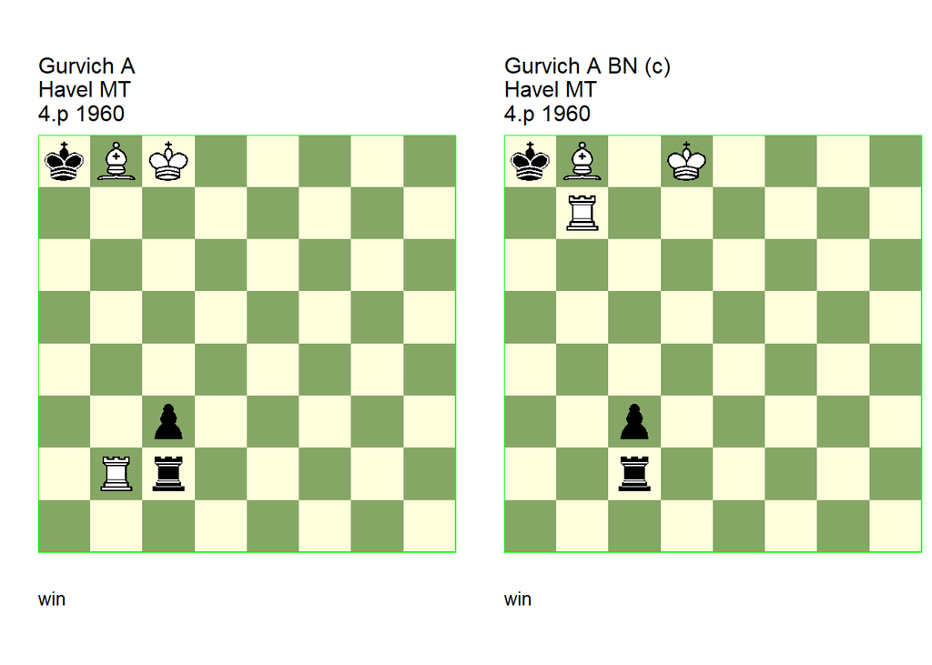

GBR: +0410.01c8a8 U1 FEN: kBK5/8/8/8/8/2p5/1Rr5/8 w - - 0 1

(EG#07949). U1: Neuenschwander=B beatochess 13/8/2025. **1. Rb7** (1. Rb6/b5/b4 **cook** **BN** ) **1… Ra2 2. Ba7! Ra6** (2… Rd2 **main** 3. Bb6! Rg2 4. Bd4 Rg8+ 5. Kc7) (2… Ra4 **main** 3. Bc5!) (2… Rxa7 3. Rb8#) (2… Re2 **main** 3. Bc5! Re8+ 4. Kc7) (2… Rg2 **main** 3. Bd4! Rg8+ 4. Kc7) **3. Bb6! Ra4 4. Rb8# 1-0**.

GBR: +0410.01d8a8 (c) FEN: kB1K4/1R6/8/8/8/2p5/2r5/8 w - - 0 1

correction: Neuenschwander=B beatochess 13/08/2025. **1. Kc8** (1. Kc7 Ra2) **1… Ra2 2. Ba7 Ra6 3. Bb6 1-0**.

Date: August 13, 2025

File: Pachman1960a.pgn

**5. Rg7!** cooks the study.

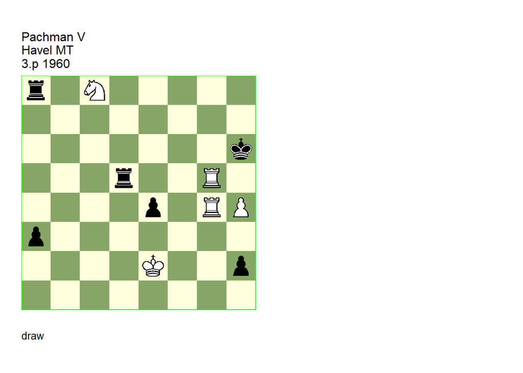

GBR: =0801.13e2h6 U2 FEN: r1N5/8/7k/3r2R1/4p1RP/p7/4K2p/8 w - - 0 1

(EG#07948). U2: Neuenschwander=B beatochess 13/08/2025. **1. Rg8 Rd7** (1… Kh5 2. Rg2) **2. Rh8+ Rh7 3. Ne7! Kh5** (3… Rhxh8 4. Nf5+ Kh7 5. Rg7#) **4. Rg5+ Kxh4 5. Rg2!** (5. Rg7! **cook** **BN** ) **5… Raxh8** (5… Rhxh8 **main** 6. Nf5+ Kh5 7. Ng7+ Kh6 8. Nf5+) **6. Ng6+ Kh3 7. Nf4+ Kh4 8. Ng6+ Kh5 9. Nf4+ 1/2-1/2**.

### Micu =0407.21d8e3 (1987). Cook

Date: August 12, 2025

File: Micu1987b.pgn

**8… Rc3!** cooks the study.

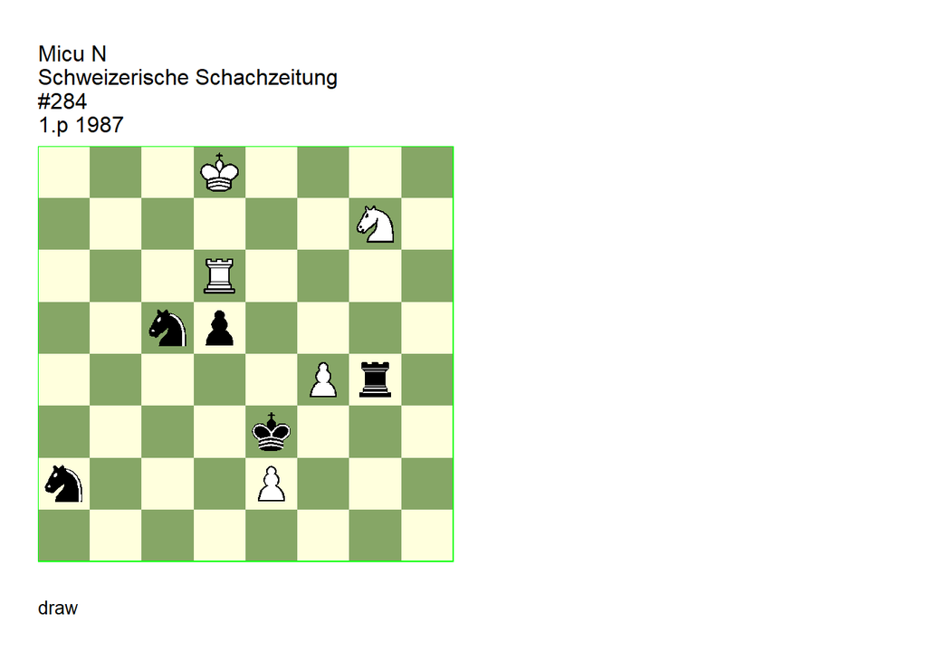

GBR: =0407.21d8e3 U3 FEN: 3K4/6N1/3R4/2np4/5Pr1/4k3/n3P3/8 w - - 0 1

Schweizerische Schachzeitung=6 Schweizerische Schachzeitung/6 1988 (EG#07921). U3: Neuenschwander=B beatochess 12/08/2025. **1. Nf5+** (1. Rxd5? Nb7+ 2. Kc7 ( 2. Kc8 Rxg7 3. f5 Nb4!) 2… Rxg7+ 3. Rd7 Rxd7+ 4. Kxd7 Kxf4 5. e4 Ke5) **1… Ke4!** (1… Kxf4 2. Rxd5 Rg8+ 3. Kc7) **2. Rxd5! Rg8+ 3. Kc7 Nb4 4. Rxc5** (4. Rd4+? Kxf5 5. Rxb4 Na6+) **4… Na6+ 5. Kc6** (5. Kb6? Nxc5 6. Nd6+ Kd4 7. e3+ Kd5) **5… Rc8+** (5… Nxc5 6. Nd6+ Kd4 7. e3+) **6. Kb6 Rxc5 7. Ng7!** (7. Ne7? Rc2 8. Kxa6 Rc7 9. Ng8 Kxf4) (7. Ng3+? Kxf4 8. Nf1 Rc2 9. Kxa6 Rxe2) (7. Nd6+? Kd5 8. Nb7 Rc6+) **7… Rc7** (7… Rc8 8. Kxa6 Rg8 9. Nh5 Rg6+ 10. Kb5 Kf5 11. e3 Kg4 12. f5) **8. Nh5!** (8. Ne6? Re7 9. Ng5+ Kxf4) (8. Ne8? Re7) **8… Rc8** (8… Rc3! **cook** **BN** 9. Kxa6 Kf5 10. Ng7+ Kg6 11. Ne8 Rc8) **9. Ng7** (9. f5? Kxf5 10. Kxa6 Kg5 11. Ng3 Kf4) **9… Rc7 10. Nh5 1/2-1/2**.

### Gillberg +0403.31e8d4 (1986). Correction

Date: August 12, 2025

File: Gillberg1986a.pgn

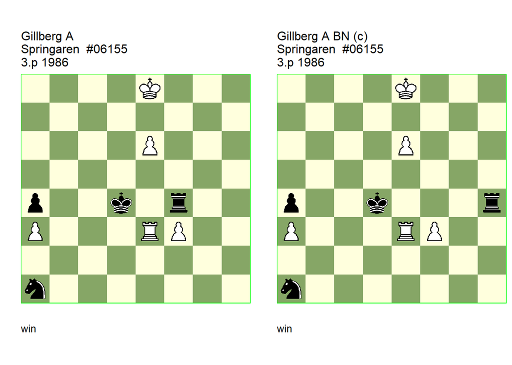

GBR: +0403.31e8d4 U3 FEN: 4K3/8/4P3/8/p2k1r2/P3RP2/8/n7 w - - 0 1

Springaren=30 Springaren/9 1987 (EG#07913). U3: Van, der, Heijden=H HHdbV#27379 10-1-2014. **1. Re1!** (1. Re4+? Rxe4 2. fxe4 Nb3 3. e7 Nc5 4. e5 Ne6 5. Kf7 (5. Kd7 Ng7) 5… Nc7) (1. Re2? Rxf3) (1. e7? Kxe3 2. Kd8 Kxf3 3. e8=Q Nb3) **1… Nc2!** (1… Nb3 2. e7) (1… Rxf3! **cook** HH 2. e7 Nc2 3. Rd1+ (3. Re2 Kd3) 3… Kc3) **2. Re4+** (2. e7? Nxe1 3. Kd8 Nxf3 4. e8=Q Kd3) (2. Rd1+? Kc3 3. e7 Rxf3 4. Kd8 Re3) (2. Rc1? Nxa3 3. e7 Rxf3 4. Kd8 Re3) **2… Rxe4 3. fxe4 Ne3! 4. e7!** (4. Kf8? Nc4) (4. Kf7? Nc4) (4. Kd7? Ng4) (4. Kd8? Ng4) **4… Ng4** (4… Nc4 **main** 5. Kd7!) **5. Kf7! 1-0**.

GBR: +0403.31e8d4 FEN: 4K3/8/4P3/8/p2k3r/P3RP2/8/n7 w - - 0 1

correction: Neuenschwander=B beatochess 12/08/2025. **1. Re1!** (1. Re4+? Rxe4 2. fxe4 Nb3 3. e7 Nc5 4. e5 Ne6 5. Kf7 (5. Kd7 Ng7) 5… Nc7) (1. Re2? Rh8+ 2. Kd7 Kd3 3. Re5 Nc2 4. e7 Nxa3) **1… Nc2! 2. Re4+ Rxe4 3. fxe4 Ne3! 4. e7!** (4. Kf8? Nc4) (4. Kf7? Nc4) (4. Kd7? Ng4) (4. Kd8? Ng4) **4… Ng4** (4… Nc4 **main** 5. Kd7!) **5. Kf7! 1-0**.

### Rumyantsev =0444.10h8g5 (1987). Cook

Date: August 10, 2025

File: Rumyantsev1987a.pgn

It is unclear how Black wins after **1. Ra1** (or Rb2) because White has an important check on the 6th rank.

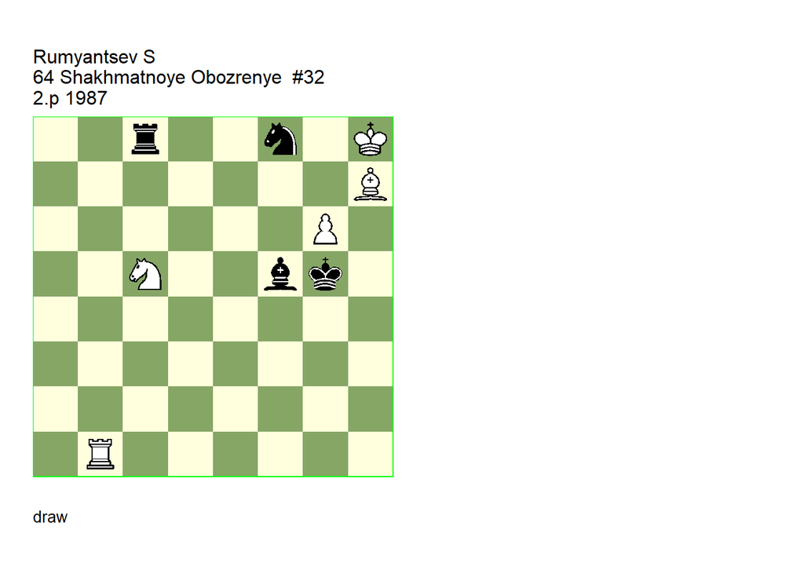

GBR: =0444.10h8g5 U1 FEN: 2r2n1K/7B/6P1/2N2bk1/8/8/8/1R6 w - - 0 1

64 Shakhmatnoye Obozrenye=8(775) 64 Shakhmatnoye Obozrenye/4 (EG#07835). U1: Neuenschwander=B beatochess 10/08/2025. **1. Rc1!** (1. Rg1+? Kf6 2. Ne4+ Bxe4 3. Rf1+ Bf5 4. Rxf5+ Kxf5 5. g7+ Ng6#) (1. Rf1? Nxg6+ 2. Kg7 Rc7+ 3. Kg8 Rxc5 4. Bxg6 Kxg6) (1. Ra1! **cook** **BN** 1… Nxg6+ (1… Ne6+ 2. Bg8 Nxc5 3. Kg7) 2. Kg7 Rc7+ 3. Kg8 Rxc5 (3… Kf6 4. Ra6+) 4. Bxg6 Kxg6 5. Ra6+) **1… Nxg6+ 2. Kg7 Rc7+ 3. Kg8 Kf6! 4. Ne4+ Bxe4! 5. Bxg6! Bd5+** (5… Rg7+ 6. Kf8 Rxg6 7. Rc6+ Bxc6) **6. Bf7 Bxf7+ 7. Kf8 Bc4 8. Ke8 Rc8+** (8… Bb5+ **main** 9. Kd8 Rxc1) **9. Kd7 Be6+ 10. Kd6 Rxc1 1/2-1/2**.

### Kuzmin & Umnov =0323.00h1g7 (1987). Cook/dual

Date: August 9, 2025

File: Kuzmin1987a.pgn

In the second mainline **3… Kf8**, **7. Bb3!** draws as well; strictly speaking a cook, but demoting this line to a sideline fixes the problem.

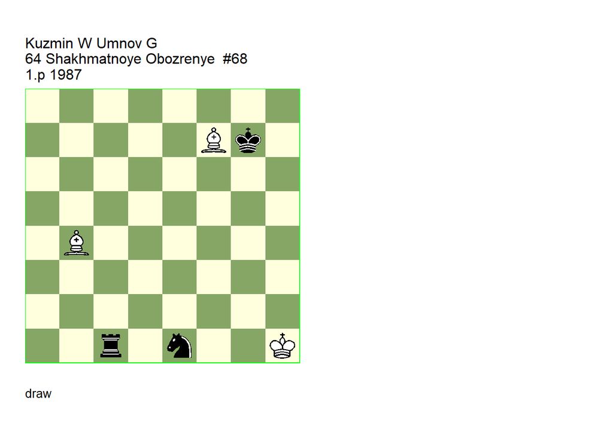

GBR: =0323.00h1g7 (U2) FEN: 8/5Bk1/8/8/1B6/8/8/2r1n2K w - - 0 1

64 Shakhmatnoye Obozrenye=17(784) 64 Shakhmatnoye Obozrenye/9 (EG#07834). (U2): Neuenschwander=B beatochess 09/08/2025. **1. Ba3 Rb1 2. Ba2 Rd1 3. Bb2+!** (3. Bb3? Nc2+ 4. Kg2 Rd2+) **3… Kg6** (3… Kf8 **main** 4. Ba3+ Ke8 5. Bc5! Nd3+ (5… Rd2 6. Bb3! Nf3 7. Bg1 Rb2 8. Bd5) 6. Bg1 Nf4! 7. Bc4 (7. Bb3? Ra1! 8. Kh2 Ra3! 9. Be3 Ne2) (7. Bb3! **cook** **BN** 7… Ra1 (7… Rb1 8. Ba4+) 8. Bc4 += TB ) 7… Nh3 8. Kg2 Nxg1 9. Bf1! Nh3 10. Bb5+ Ke7 11. Kxh3) (3… Kh6 4. Bc3! Nd3+ 5. Kg2 Rc1 6. Bd2+) **4. Bc3! Nd3+! 5. Kg2 Rc1 6. Bd2! Rc2 7. Bb1! Rxd2+ 8. Kf3 Rd1 9. Bc2 Rd2 10. Bb1 1/2-1/2**.

### Balanovsky & Rezvov +3231.02b1a3 (1987). Cook, comment

Date: August 8, 2025

File: Balanovsky1987a.pgn

After **8… Bf8**, **9. Re3** wins as well because of the treat Rb3. The study can be saved by making 8… Bf8 a sideline and only keeping the two mainlines **8… Qh5** and **8… Bd4**, which also seems more thematic (two mates)

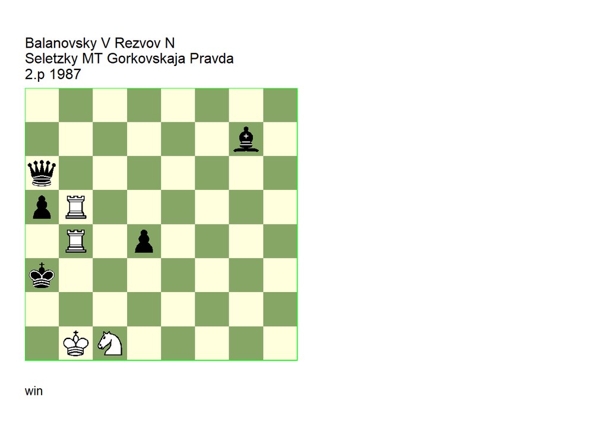

GBR: +3231.02b1a3 U2 FEN: 8/6b1/q7/pR6/1R1p4/k7/8/1KN5 w - - 0 1

(EG#07825. U2: Neuenschwander=B beatochess 08/08/2025). **1. Rb2 Qg6+ 2. Ka1 Ka4 3. Rb6! d3!** (3… Qxb6 4. Rxb6 d3+ 5. Ka2! d2 6. Nd3! d1=Q 7. Nc5#) **4. Rxg6 d2 5. Rg4+** (5. Rg1? dxc1=Q+ 6. Rxc1 Ka3 7. Rc2 a4! 8. Kb1 Bxb2 9. Rxb2) (5. Nd3? d1=Q+ 6. Ka2 Qxd3 7. Rg4+ Bd4!) **5… Ka3 6. Rg3+ Ka4 7. Nd3! d1=Q+ 8. Ka2 Bf8** (8… Bd4 **main** 9. Nf2! Bxf2 10. Ra3#) (8… Qh5 **main** 9. Rg4+! Qxg4 10. Nc5#) **9. Rb4+!** (9. Re3! **cook** **BN** ) **9… Bxb4 10. Nb2+ 1-0**.

### Nestorescu +0010.24c8d3 (1987). Correction

Date: July 21, 2025

File: Nestorescu1987a.pgn

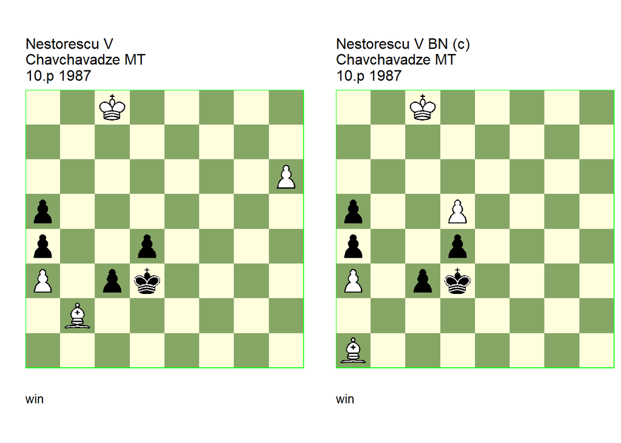

GBR: +0010.24c8d3 U2 FEN: 2K5/8/7P/p7/p2p4/P1pk4/1B6/8 w - - 0 1

(EG#07744). U2: Garcia=M HHdbV#26127 24-9-2011. **1. Ba1 Kc2 2. h7 Kb1 3. h8=Q c2 4. Qxd4** (4. Qh1+! **cook** MG 4… c1=Q+ 5. Qxc1+ Kxc1 6. Bxd4 Kc2 7. Kd7 Kd3 8. Be5 Ke4 (8… Kc4 9. Kc6 Kb3 10. Bd6 Kc4 11. Bc5) 9. Ke6) **4… c1=Q+ 5. Bc3 Qxa3** (5… Ka2 **main** 6. Qc4+ Kxa3 7. Bb4+ Kb2 8. Ba3+) **6. Qd3+ Kc1 7. Bd2+ Kb2 8. Bc1+ 1-0**.

GBR: +0010.24c8d3 (c) FEN: 2K5/8/8/p2P4/p2p4/P1pk4/8/B7 w - - 0 1

correction: Neuenschwander=B beatochess 21/07/2025. **1. d6 Kc2 2. d7 Kb1 3. d8=Q c2 4. Qxd4 c1=Q+ 5. Bc3 Qxa3** (5… Ka2 **main** 6. Qc4+ Kxa3 7. Bb4+ Kb2 8. Ba3+) **6. Qd3+ Kc1 7. Bd2+ Kb2 8. Bc1+ 1-0**.